# Pertemuan 1 - Pemulusan

Muhammad Abshor Dzulhij Rizki_G1401221038

## Library / Packages

*Package* R yang akan digunakan pada perkuliahan Analisis Deret Waktu sesi UTS adalah: `forecast`, `graphics`, `TTR`, `TSA` . Jika *package* tersebut belum ada, silakan install terlebih dahulu.

```r
#install.packages("forecast")
#install.packages("graphics")
#install.packages("TTR")
#install.packages("TSA")
```

Jika sudah ada, silakan panggil library *package* tersebut.

```r
library("forecast")
```

```r
library("graphics")
library("TTR")
library("TSA")
```

## Impor Data

```r
#install.packages("rio") #install jika belum ada
library(rio)
data1 <- rio::import("C:/Users/Irsyad Parama/Downloads/data hujan bogor.xlsx")
```

## Eksplorasi Data

Melihat data menggunakan fungsi `View()`, struktur data menggunakan fungsi `str()`, dan dimensi data menggunakan fungsi `dim()`.

```r
View(data1)
str(data1)
```

```
## 'data.frame':    602 obs. of  2 variables:
##  $ Tanggal        : chr  "1-Jan" "2-Jan" "3-Jan" "4-Jan" ...
##  $ Akumulasi Hujan: num  13.629 54.156 52.432 17.863 0.648 ...
```

```r
dim(data1)
```

```
## [1] 602   2
```

Mengubah data agar terbaca sebagai data deret waktu dengan fungsi `ts()` .

```r
data1.ts <- ts(data1$`Akumulasi Hujan`)
```

Menampilkan ringkasan data

```r
summary(data1.ts)
```

```
##     Min.  1st Qu.   Median     Mean  3rd Qu.     Max.
##   0.0000   0.0318   3.6939  29.0996  33.3553 379.7904
```

Membuat plot data deret waktu

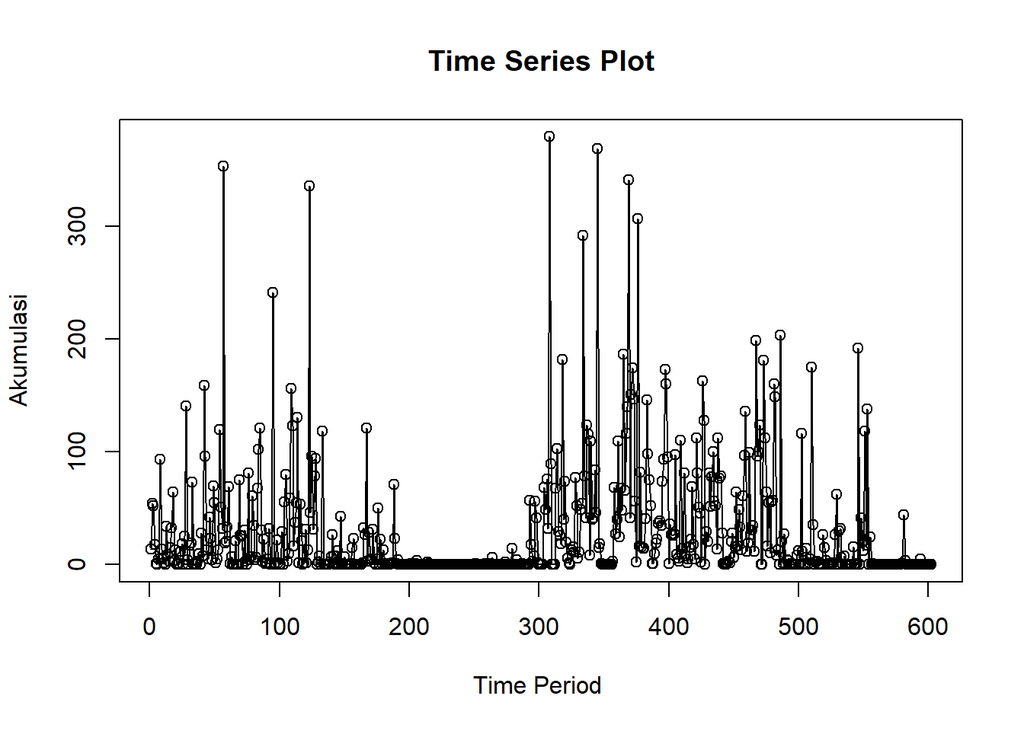

```r
ts.plot(data1.ts, xlab="Time Period ", ylab="Akumulasi",
        main = "Time Series Plot")
points(data1.ts)
```

## Single Moving Average & Double Moving Average

### Pembagian Data

Pembagian data latih dan data uji dilakukan dengan perbandingan 80% data latih dan 20% data uji.

```r
#membagi data latih dan data uji
training_ma <- data1[363:459,]
testing_ma <- data1[460:483,]
train_ma.ts <- ts(training_ma[["Akumulasi Hujan"]], start=c(363), frequency=1)
test_ma.ts <- ts(testing_ma[["Akumulasi Hujan"]], start=c(460), frequency=1)
```

### Eksplorasi Data

Eksplorasi data dilakukan pada keseluruhan data, data latih serta data uji menggunakan plot data deret waktu.

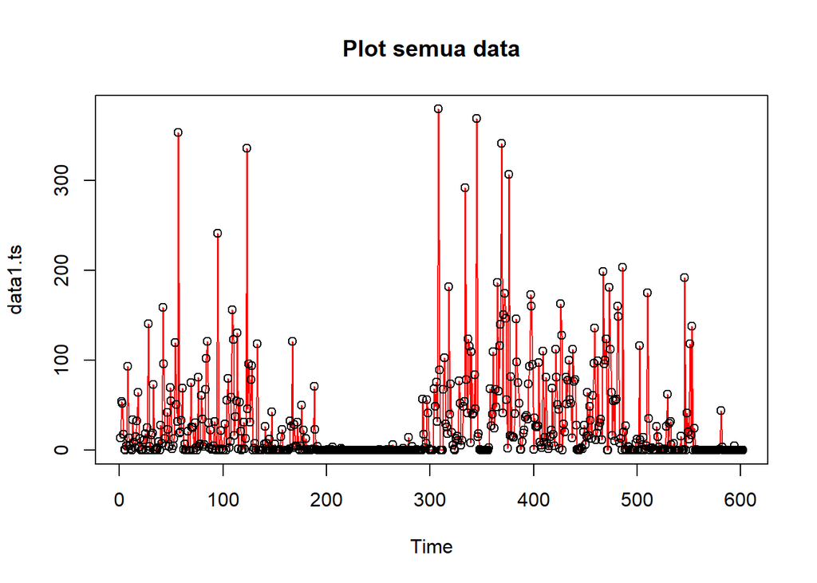

```r
#eksplorasi keseluruhan data
plot(data1.ts, col="red",main="Plot semua data")
points(data1.ts)
```

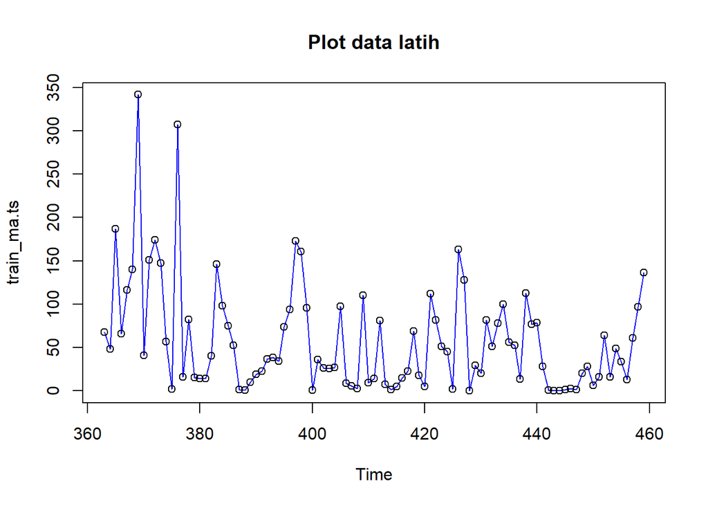

```r
#eksplorasi data latih
plot(train_ma.ts, col="blue",main="Plot data latih")
points(train_ma.ts)
```

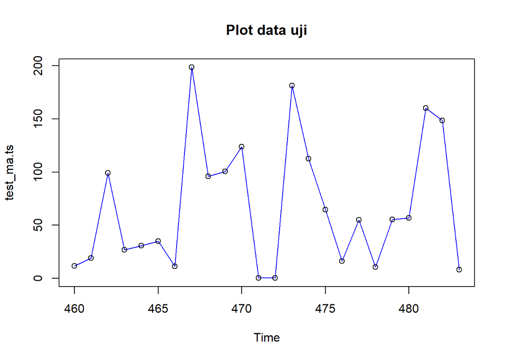

```r
#eksplorasi data uji
plot(test_ma.ts, col="blue",main="Plot data uji")
points(test_ma.ts)
```

### Single Moving Average (SMA)

Ide dasar dari Single Moving Average (SMA) adalah data suatu periode dipengaruhi oleh data periode sebelumnya. Metode pemulusan ini cocok digunakan untuk pola data stasioner atau konstan. Prinsip dasar metode pemulusan ini adalah data pemulusan pada periode ke-t merupakan rata rata dari m buah data pada periode ke-t hingga periode ke (t-m+1). Data pemulusan pada periode ke-t selanjutnya digunakan sebagai nilai peramalan pada periode ke t+1

Pemulusan menggunakan metode SMA dilakukan dengan fungsi `SMA()`. Dalam hal ini akan dilakukan pemulusan dengan parameter `m=4`.

```r
data.sma<-SMA(train_ma.ts, n=4)
data.sma
```

```
## Time Series:
## Start = 363
## End = 459
## Frequency = 1
##  [1]          NA          NA          NA  92.1677250 104.3779000 127.3716500
##  [7] 166.0119500 159.7989500 168.4839250 176.9768750 128.3375750 132.1978750
## [13]  94.9185500 128.1608750  95.4545500 101.8266000 105.2620750  31.9914250
## [19]  31.5149000  21.1071750  53.6939750  74.6895500  89.9102000  92.8821000
## [25]  56.6706750  32.3958250  16.0735500   7.7038500  13.0727250  22.0541500
## [31]  29.2201750  33.0943000  45.8697000  60.0436500  93.6823000 125.2213000
## [37] 130.7416000 107.5021250  73.2724250  39.7702000  22.2597500  28.8143000
## [43]  44.1510750  39.6888500  34.6632250  28.6052000  31.8152750  31.9404250
## [49]  34.1155250  53.7068750  27.9368250  25.9920000  23.6551250   7.1290250
## [55]  10.9263500  27.8271500  30.9582250  28.4923750  50.8994250  54.0546375
## [61]  62.4124125  72.4379125  44.8777875  65.2487500  84.4429750  73.2164250
## [67]  80.1079750  44.4190250  32.8370500  45.5908750  57.6988000  77.6772500
## [73]  71.3869750  71.6361250  55.5846500  58.7038500  63.8594500  70.4455500
## [79]  74.0088500  46.0660000  26.9704125   7.3279625   0.7001375   1.1799125
## [85]   1.4367500   6.5174500  13.1382000  14.0280000  17.6103250  28.5296000
## [91]  25.5919250  36.1423000  40.5572500  27.8502000  39.0054250  51.0650000
## [97]  76.7787250
```

Data pemulusan pada periode ke-t selanjutnya digunakan sebagai nilai peramalan pada periode ke t+1 sehingga hasil peramalan 1 periode kedepan adalah sebagai berikut.

```r
data.ramal<-c(NA,data.sma)
data.ramal #forecast 1 periode ke depan
```

```
##  [1]          NA          NA          NA          NA  92.1677250 104.3779000
##  [7] 127.3716500 166.0119500 159.7989500 168.4839250 176.9768750 128.3375750
## [13] 132.1978750  94.9185500 128.1608750  95.4545500 101.8266000 105.2620750
## [19]  31.9914250  31.5149000  21.1071750  53.6939750  74.6895500  89.9102000
## [25]  92.8821000  56.6706750  32.3958250  16.0735500   7.7038500  13.0727250
## [31]  22.0541500  29.2201750  33.0943000  45.8697000  60.0436500  93.6823000
## [37] 125.2213000 130.7416000 107.5021250  73.2724250  39.7702000  22.2597500
## [43]  28.8143000  44.1510750  39.6888500  34.6632250  28.6052000  31.8152750
## [49]  31.9404250  34.1155250  53.7068750  27.9368250  25.9920000  23.6551250
## [55]   7.1290250  10.9263500  27.8271500  30.9582250  28.4923750  50.8994250
## [61]  54.0546375  62.4124125  72.4379125  44.8777875  65.2487500  84.4429750
## [67]  73.2164250  80.1079750  44.4190250  32.8370500  45.5908750  57.6988000
## [73]  77.6772500  71.3869750  71.6361250  55.5846500  58.7038500  63.8594500
## [79]  70.4455500  74.0088500  46.0660000  26.9704125   7.3279625   0.7001375
## [85]   1.1799125   1.4367500   6.5174500  13.1382000  14.0280000  17.6103250
## [91]  28.5296000  25.5919250  36.1423000  40.5572500  27.8502000  39.0054250
## [97]  51.0650000  76.7787250
```

Selanjutnya akan dilakukan peramalan sejumlah data uji yaitu 24 periode. Pada metode SMA, hasil peramalan 24 periode ke depan akan bernilai sama dengan hasil peramalan 1 periode kedepan. Dalam hal ini akan dilakukan pengguabungan data aktual train, data hasil pemulusan dan data hasil ramalan 24 periode kedepan.

```r
data.gab<-cbind(aktual=c(train_ma.ts,rep(NA,24)),pemulusan=c(data.sma,rep(NA,24)),ramalan=c(data.ramal,rep(data.ramal[length(data.ramal)],23)))
data.gab #forecast 24 periode ke depan
```

```
##           aktual   pemulusan     ramalan
##   [1,]  67.40330          NA          NA
##   [2,]  48.29790          NA          NA
##   [3,] 187.03570          NA          NA
##   [4,]  65.93400  92.1677250          NA
##   [5,] 116.24400 104.3779000  92.1677250
##   [6,] 140.27290 127.3716500 104.3779000
##   [7,] 341.59690 166.0119500 127.3716500
##   [8,]  41.08200 159.7989500 166.0119500
##   [9,] 150.98390 168.4839250 159.7989500
##  [10,] 174.24470 176.9768750 168.4839250
##  [11,] 147.03970 128.3375750 176.9768750
##  [12,]  56.52320 132.1978750 128.3375750
##  [13,]   1.86660  94.9185500 132.1978750
##  [14,] 307.21400 128.1608750  94.9185500
```

[output cut: 107 more lines]

Adapun plot data deret waktu dari hasil peramalan yang dilakukan adalah sebagai berikut.

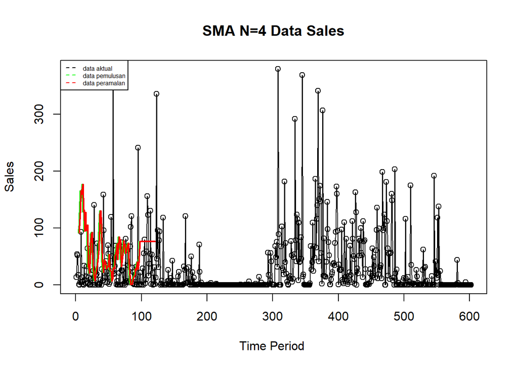

```r
ts.plot(data1.ts, xlab="Time Period ", ylab="Sales", main= "SMA N=4 Data Sales")
points(data1.ts)
lines(data.gab[,2],col="green",lwd=2)
lines(data.gab[,3],col="red",lwd=2)
legend("topleft",c("data aktual","data pemulusan","data peramalan"), lty=8, col=c("black","green","red"), cex=0.5)
```

Selanjutnya perhitungan akurasi dilakukan dengan ukuran akurasi *Sum Squares Error* (SSE), *Mean Square Error* (MSE) dan *Mean Absolute Percentage Error* (MAPE). Perhitungan akurasi dilakukan baik pada data latih maupun pada data uji.

```r
#Menghitung nilai keakuratan data latih
error_train.sma = train_ma.ts-data.ramal[1:length(train_ma.ts)]
SSE_train.sma = sum(error_train.sma[5:length(train_ma.ts)]^2)
MSE_train.sma = mean(error_train.sma[5:length(train_ma.ts)]^2)
MAPE_train.sma = mean(abs((error_train.sma[5:length(train_ma.ts)]/train_ma.ts[5:length(train_ma.ts)])*100))

akurasi_train.sma <- matrix(c(SSE_train.sma, MSE_train.sma, MAPE_train.sma))
row.names(akurasi_train.sma)<- c("SSE", "MSE", "MAPE")
colnames(akurasi_train.sma) <- c("Akurasi m = 4")
akurasi_train.sma
```

```
##      Akurasi m = 4
## SSE     346979.699
## MSE       3730.965
## MAPE      1824.337
```

Dalam hal ini nilai MAPE data latih pada metode pemulusan SMA lebih dari 10%, nilai ini dapat dikategorikan sebagai nilai akurasi yang tidak baik karena memiliki ketimpangan antar value yang sangat besar dan di indikasikan oleh nilai 0 yang sangat banyak sehingga perlu di transformasi atau dinormalisasi.Ini bisa berarti bahwa model tidak memprediksi dengan baik atau ada faktor-faktor tertentu yang mempengaruhi akurasi model secara negatif.

```r
#Menghitung nilai keakuratan data uji
error_test.sma = test_ma.ts-data.gab[97:120,3]
SSE_test.sma = sum(error_test.sma^2)
MSE_test.sma = mean(error_test.sma^2)
MAPE_test.sma = mean(abs((error_test.sma/test_ma.ts*100)))

akurasi_test.sma <- matrix(c(SSE_test.sma, MSE_test.sma, MAPE_test.sma))
row.names(akurasi_test.sma)<- c("SSE", "MSE", "MAPE")
colnames(akurasi_test.sma) <- c("Akurasi m = 4")
akurasi_test.sma
```

```
##      Akurasi m = 4
## SSE      84396.822
## MSE       3516.534
## MAPE      2305.237
```

Dalam hal ini nilai MAPE data uji pada metode pemulusan SMA lebih dari 10%, nilai ini dapat dikategorikan sebagai nilai akurasi yang tidak baik karena memiliki ketimpangan antar value yang sangat besar dan di indikasikan oleh nilai 0 yang sangat banyak sehingga perlu di transformasi atau dinormalisasi.Ini bisa berarti bahwa model tidak memprediksi dengan baik atau ada faktor-faktor tertentu yang mempengaruhi akurasi model secara negatif.

### Double Moving Average (DMA)

Metode pemulusan Double Moving Average (DMA) pada dasarnya mirip dengan SMA. Namun demikian, metode ini lebih cocok digunakan untuk pola data trend. Proses pemulusan dengan rata rata dalam metode ini dilakukan sebanyak 2 kali.

```r
dma <- SMA(data.sma, n = 4)
At <- 2*data.sma - dma
Bt <- 2/(4-1)*(data.sma - dma)
data.dma<- At+Bt
data.ramal2<- c(NA, data.dma)

t = 1:24
f = c()

for (i in t) {
  f[i] = At[length(At)] + Bt[length(Bt)]*(i)
}

data.gab2 <- cbind(aktual = c(train_ma.ts,rep(NA,24)), pemulusan1 = c(data.sma,rep(NA,24)),pemulusan2 = c(data.dma, rep(NA,24)),At = c(At, rep(NA,24)), Bt = c(Bt,rep(NA,24)),ramalan = c(data.ramal2, f[-1]))
data.gab2
```

```
##           aktual  pemulusan1  pemulusan2          At          Bt     ramalan
##   [1,]  67.40330          NA          NA          NA          NA          NA
##   [2,]  48.29790          NA          NA          NA          NA          NA
##   [3,] 187.03570          NA          NA          NA          NA          NA
##   [4,]  65.93400  92.1677250          NA          NA          NA          NA
##   [5,] 116.24400 104.3779000          NA          NA          NA          NA
##   [6,] 140.27290 127.3716500          NA          NA          NA          NA
##   [7,] 341.59690 166.0119500 238.5613562 209.5415937  29.0197625          NA
##   [8,]  41.08200 159.7989500 193.8136792 180.2077875  13.6058917 238.5613562
##   [9,] 150.98390 168.4839250 190.2627687 181.5512312   8.7115375 193.8136792
##  [10,] 174.24470 176.9768750 192.2417917 186.1358250   6.1059667 190.2627687
##  [11,] 147.03970 128.3375750  78.2346479  98.2758187 -20.0411708 192.2417917
##  [12,]  56.52320 132.1978750 100.0292292 112.8966875 -12.8674583  78.2346479
##  [13,]   1.86660  94.9185500  31.2699354  56.7293812 -25.4594458 100.0292292
##  [14,] 307.21400 128.1608750 140.2561354 135.4180312   4.8381042  31.2699354
```

[output cut: 107 more lines]

Hasil pemulusan menggunakan metode DMA divisualisasikan sebagai berikut

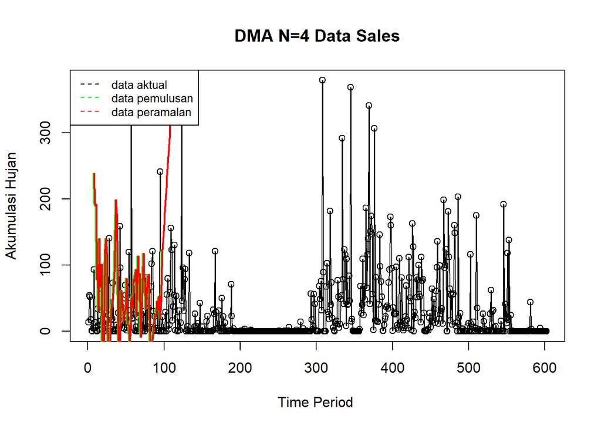

```r
ts.plot(data1.ts, xlab="Time Period ", ylab="Akumulasi Hujan", main= "DMA N=4 Data Sales")
points(data1.ts)
lines(data.gab2[,3],col="green",lwd=2)
lines(data.gab2[,6],col="red",lwd=2)
legend("topleft",c("data aktual","data pemulusan","data peramalan"), lty=8, col=c("black","green","red"), cex=0.8)
```

Selanjutnya perhitungan akurasi dilakukan baik pada data latih maupun data uji. Perhitungan akurasi dilakukan dengan ukuran akurasi SSE, MSE dan MAPE.

```r
#Menghitung nilai keakuratan data latih
error_train.dma = train_ma.ts-data.ramal2[1:length(train_ma.ts)]
SSE_train.dma = sum(error_train.dma[8:length(train_ma.ts)]^2)
MSE_train.dma = mean(error_train.dma[8:length(train_ma.ts)]^2)
MAPE_train.dma = mean(abs((error_train.dma[8:length(train_ma.ts)]/train_ma.ts[8:length(train_ma.ts)])*100))

akurasi_train.dma <- matrix(c(SSE_train.dma, MSE_train.dma, MAPE_train.dma))
row.names(akurasi_train.dma)<- c("SSE", "MSE", "MAPE")
colnames(akurasi_train.dma) <- c("Akurasi m = 4")
akurasi_train.dma
```

```
##      Akurasi m = 4
## SSE     449244.054
## MSE       4991.601
## MAPE      1884.524
```

Dalam hal ini nilai MAPE data latih pada metode pemulusan DMA lebih dari 10%, nilai ini dapat dikategorikan sebagai nilai akurasi yang tidak baik karena memiliki ketimpangan antar value yang sangat besar dan di indikasikan oleh nilai 0 yang sangat banyak sehingga perlu di transformasi atau dinormalisasi.Ini bisa berarti bahwa model tidak memprediksi dengan baik atau ada faktor-faktor tertentu yang mempengaruhi akurasi model secara negatif.

```r
#Menghitung nilai keakuratan data uji
error_test.dma = test_ma.ts-data.gab2[97:120,6]
SSE_test.dma = sum(error_test.dma^2)
MSE_test.dma = mean(error_test.dma^2)
MAPE_test.dma = mean(abs((error_test.dma/test_ma.ts*100)))

akurasi_test.dma <- matrix(c(SSE_test.dma, MSE_test.dma, MAPE_test.dma))
row.names(akurasi_test.dma)<- c("SSE", "MSE", "MAPE")
colnames(akurasi_test.dma) <- c("Akurasi m = 4")
akurasi_test.dma
```

```
##      Akurasi m = 4
## SSE    1956174.542
## MSE      81507.273
## MAPE      9805.169
```

Dalam hal ini nilai MAPE data tes pada metode pemulusan DMA lebih dari 10%, nilai ini dapat dikategorikan sebagai nilai akurasi yang tidak baik karena memiliki ketimpangan antar value yang sangat besar dan di indikasikan oleh nilai 0 yang sangat banyak sehingga perlu di transformasi atau dinormalisasi.Ini bisa berarti bahwa model tidak memprediksi dengan baik atau ada faktor-faktor tertentu yang mempengaruhi akurasi model secara negatif.

## Single Exponential Smoothing & Double Exponential Smoothing

Metode *Exponential Smoothing* adalah metode pemulusan dengan melakukan pembobotan menurun secara eksponensial. Nilai yang lebih baru diberi bobot yang lebih besar dari nilai terdahulu. Terdapat satu atau lebih parameter pemulusan yang ditentukan secara eksplisit, dan hasil pemilihan parameter tersebut akan menentukan bobot yang akan diberikan pada nilai pengamatan. Ada dua macam model, yaitu model tunggal dan ganda.

### Pembagian Data

Pembagian data latih dan data uji dilakukan dengan perbandingan 80% data latih dan 20% data uji.

```r
#membagi training dan testing
training<-data1[363:459,]
testing<-data1[460:483,]
train.ts <- ts(training$'Akumulasi Hujan', start=c(363), frequency=6)
test.ts <- ts(testing$'Akumulasi Hujan', start=c(460), frequency=6)
```

### Eksplorasi

Eksplorasi dilakukan dengan membuat plot data deret waktu untuk keseluruhan data, data latih, dan data uji.

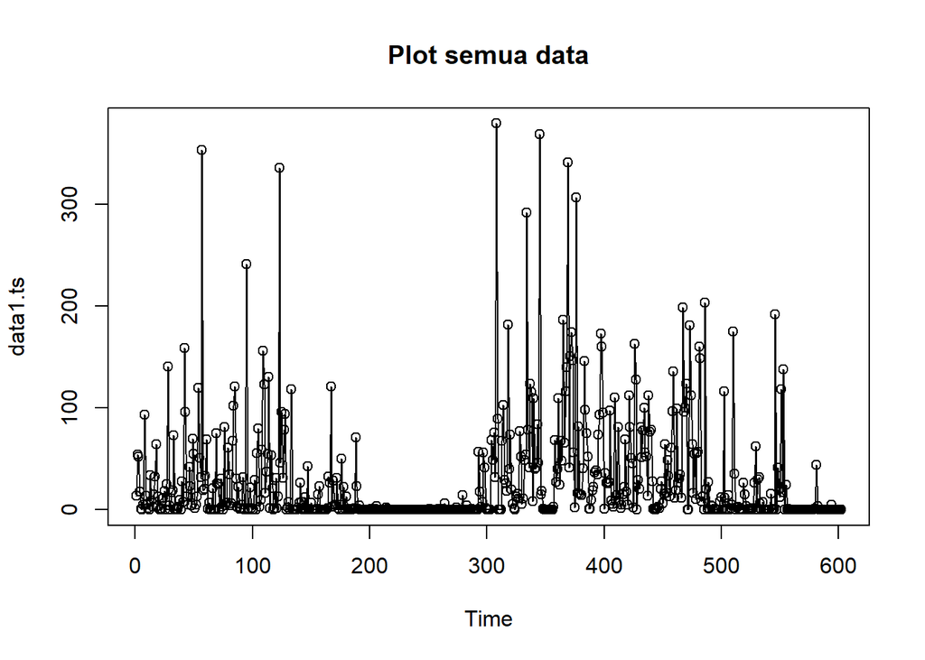

```r
#eksplorasi data
plot(data1.ts, col="black",main="Plot semua data")
points(data1.ts)
```

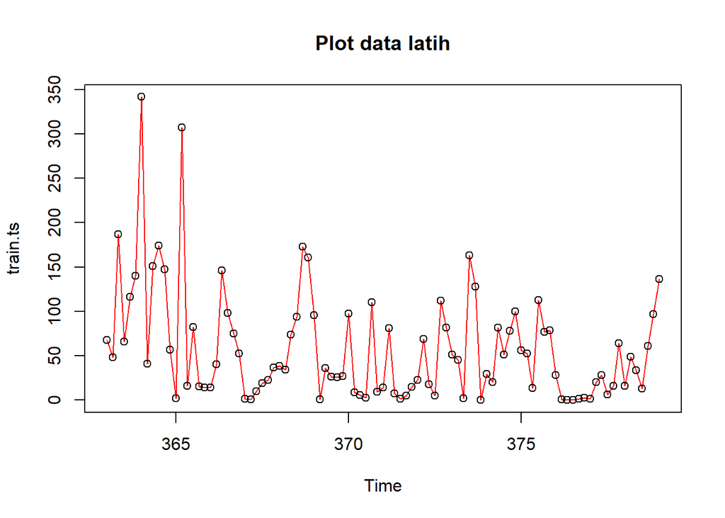

```r
plot(train.ts, col="red",main="Plot data latih")
points(train.ts)
```

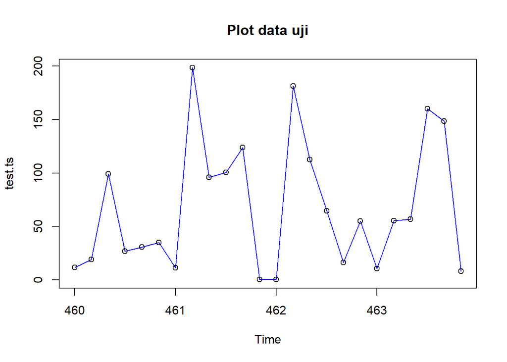

```r
plot(test.ts, col="blue",main="Plot data uji")
points(test.ts)
```

### SES

Single Exponential Smoothing merupakan metode pemulusan yang tepat digunakan untuk data dengan pola stasioner atau konstan.

Nilai pemulusan pada periode ke-t didapat dari persamaan:

$$\tilde{y}_T=\lambda y_t+(1-\lambda)\tilde{y}_{T-1}$$

Nilai parameter $\lambda$ adalah nilai antara 0 dan 1.

Nilai pemulusan periode ke-t bertindak sebagai nilai ramalan pada periode ke-$(T+\tau)$.

$$\tilde{y}_{T+\tau}(T)=\tilde{y}_T$$

Pemulusan dengan metode SES dapat dilakukan dengan dua fungsi dari *packages* berbeda, yaitu (1) fungsi `ses()` dari *packages* `forecast` dan (2) fungsi `HoltWinters` dari *packages* `stats` .

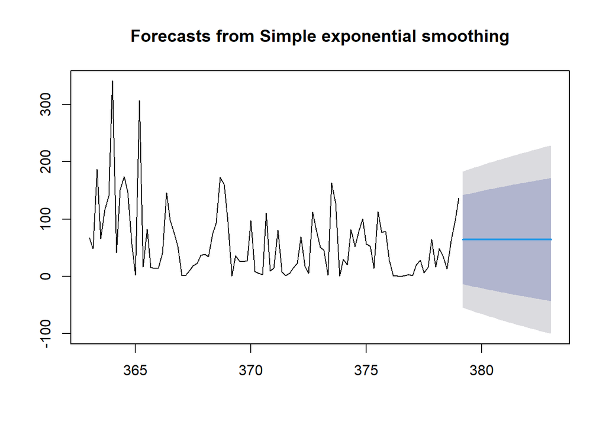

```r
#Cara 1 (fungsi ses)
ses.1 <- ses(train.ts, h = 24, alpha = 0.2)
plot(ses.1)
```

```r
ses.1
```

```
##          Point Forecast     Lo 80    Hi 80      Lo 95    Hi 95
## 379.1667        64.1651 -13.45003 141.7802  -54.53700 182.8672
## 379.3333        64.1651 -14.98711 143.3173  -56.88776 185.2180
## 379.5000        64.1651 -16.49491 144.8251  -59.19374 187.5239
## 379.6667        64.1651 -17.97503 146.3052  -61.45739 189.7876
## 379.8333        64.1651 -19.42895 147.7592  -63.68097 192.0112
## 380.0000        64.1651 -20.85802 149.1882  -65.86654 194.1967
## 380.1667        64.1651 -22.26345 150.5937  -68.01596 196.3462
## 380.3333        64.1651 -23.64640 151.9766  -70.13100 198.4612
## 380.5000        64.1651 -25.00790 153.3381  -72.21323 200.5434
## 380.6667        64.1651 -26.34892 154.6791  -74.26415 202.5943
## 380.8333        64.1651 -27.67036 156.0006  -76.28512 204.6153
## 381.0000        64.1651 -28.97306 157.3033  -78.27742 206.6076
## 381.1667        64.1651 -30.25778 158.5880  -80.24224 208.5724
## 381.3333        64.1651 -31.52526 159.8555  -82.18068 210.5109
## 381.5000        64.1651 -32.77617 161.1064  -84.09377 212.4240
## 381.6667        64.1651 -34.01114 162.3413  -85.98250 214.3127
## 381.8333        64.1651 -35.23077 163.5610  -87.84776 216.1780
## 382.0000        64.1651 -36.43561 164.7658  -89.69041 218.0206
## 382.1667        64.1651 -37.62619 165.9564  -91.51124 219.8414
## 382.3333        64.1651 -38.80301 167.1332  -93.31103 221.6412
## 382.5000        64.1651 -39.96653 168.2967  -95.09048 223.4207
## 382.6667        64.1651 -41.11719 169.4474  -96.85026 225.1805
## 382.8333        64.1651 -42.25541 170.5856  -98.59102 226.9212
## 383.0000        64.1651 -43.38158 171.7118 -100.31335 228.6436
```

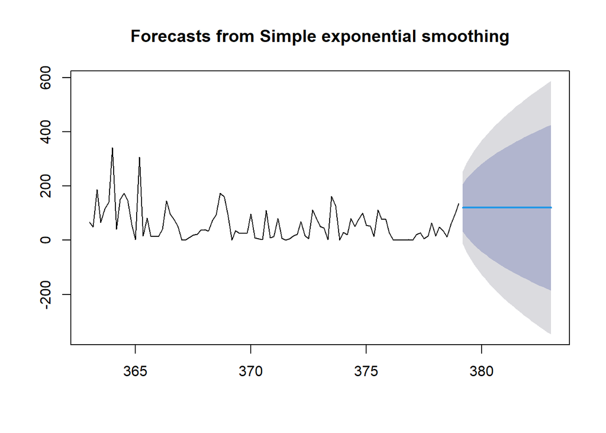

```r
ses.2<- ses(train.ts, h = 24, alpha = 0.7)
plot(ses.2)
```

```r
ses.2
```

```
##          Point Forecast       Lo 80    Hi 80      Lo 95    Hi 95
## 379.1667       120.1289   32.820727 207.4371  -13.39742 253.6552
## 379.3333       120.1289   13.555695 226.7021  -42.86075 283.1185
## 379.5000       120.1289   -2.724585 242.9824  -67.75929 308.0171
## 379.6667       120.1289  -17.086659 257.3444  -89.72418 329.9820
## 379.8333       120.1289  -30.081753 270.3395 -109.59846 349.8562
## 380.0000       120.1289  -42.038825 282.2966 -127.88523 368.1430
## 380.1667       120.1289  -53.172865 293.4306 -144.91327 385.1711
## 380.3333       120.1289  -63.633535 303.8913 -160.91149 401.1693
## 380.5000       120.1289  -73.529984 313.7878 -176.04680 416.3046
## 380.6667       120.1289  -82.944717 323.2025 -190.44539 430.7032
## 380.8333       120.1289  -91.941901 332.1997 -204.20540 444.4632
## 381.0000       120.1289 -100.572607 340.8304 -217.40492 457.6627
## 381.1667       120.1289 -108.878275 349.1361 -230.10735 470.3651
## 381.3333       120.1289 -116.893075 357.1509 -242.36492 482.6227
## 381.5000       120.1289 -124.645583 364.9034 -254.22136 494.4791
## 381.6667       120.1289 -132.159978 372.4178 -265.71364 505.9714
## 381.8333       120.1289 -139.456941 379.7147 -276.87338 517.1312
## 382.0000       120.1289 -146.554319 386.8121 -287.72788 527.9857
## 382.1667       120.1289 -153.467646 393.7254 -298.30090 538.5587
## 382.3333       120.1289 -160.210539 400.4683 -308.61327 548.8710
## 382.5000       120.1289 -166.795012 407.0528 -318.68335 558.9411
## 382.6667       120.1289 -173.231735 413.4895 -328.52747 568.7853
## 382.8333       120.1289 -179.530228 419.7880 -338.16018 578.4180
## 383.0000       120.1289 -185.699031 425.9568 -347.59455 587.8523
```

Untuk mendapatkan gambar hasil pemulusan pada data latih dengan fungsi `ses()` , perlu digunakan fungsi `autoplot()` dan `autolayer()` dari *library packages* `ggplot2` .

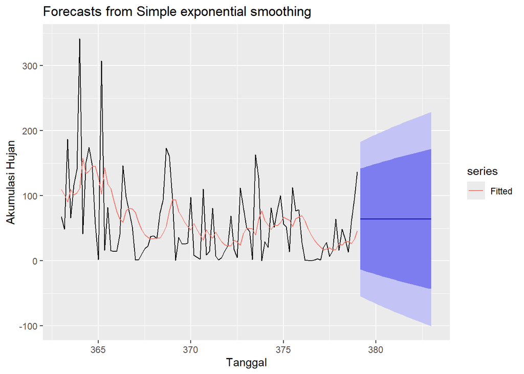

```r
library(ggplot2)
autoplot(ses.1) +
  autolayer(fitted(ses.1), series = "Fitted") +
  labs(y = "Akumulasi Hujan", x = "Tanggal")
```

Pada fungsi `ses()` , terdapat beberapa argumen yang umum digunakan, yaitu nilia `y` , `gamma` , `beta` , `alpha` , dan `h` .

Nilai `y` adalah nilai data deret waktu, `gamma` adalah parameter pemulusan untuk komponen musiman, `beta` adalah parameter pemulusan untuk tren, dan `alpha` adalah parameter pemulusan untuk stasioner, serta `h` adalah banyaknya periode yang akan diramalkan.

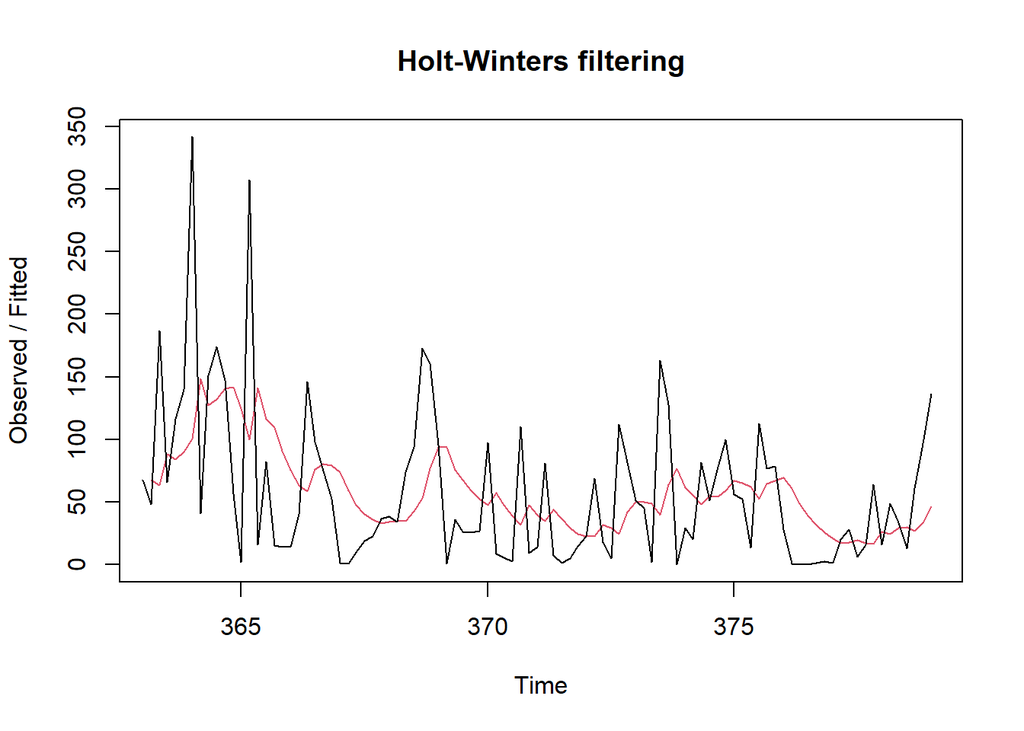

```r
#Cara 2 (fungsi Holtwinter)
ses1<- HoltWinters(train.ts, gamma = FALSE, beta = FALSE, alpha = 0.2)
plot(ses1)
```

```r
#ramalan
ramalan1<- forecast(ses1, h=24)
ramalan1
```

```
##          Point Forecast     Lo 80    Hi 80      Lo 95    Hi 95
## 379.1667        64.1651 -13.99280 142.3230  -55.36710 183.6973
## 379.3333        64.1651 -15.54064 143.8708  -57.73430 186.0645
## 379.5000        64.1651 -17.05898 145.3892  -60.05641 188.3866
## 379.6667        64.1651 -18.54945 146.8797  -62.33589 190.6661
## 379.8333        64.1651 -20.01354 148.3437  -64.57502 192.9052
## 380.0000        64.1651 -21.45259 149.7828  -66.77586 195.1061
## 380.1667        64.1651 -22.86786 151.1981  -68.94032 197.2705
## 380.3333        64.1651 -24.26047 152.5907  -71.07015 199.4003
## 380.5000        64.1651 -25.63149 153.9617  -73.16694 201.4971
## 380.6667        64.1651 -26.98190 155.3121  -75.23220 203.5624
## 380.8333        64.1651 -28.31258 156.6428  -77.26731 205.5975
## 381.0000        64.1651 -29.62438 157.9546  -79.27354 207.6037
## 381.1667        64.1651 -30.91809 159.2483  -81.25210 209.5823
## 381.3333        64.1651 -32.19444 160.5246  -83.20409 211.5343
## 381.5000        64.1651 -33.45409 161.7843  -85.13057 213.4608
## 381.6667        64.1651 -34.69770 163.0279  -87.03250 215.3627
## 381.8333        64.1651 -35.92585 164.2561  -88.91080 217.2410
## 382.0000        64.1651 -37.13912 165.4693  -90.76634 219.0965
## 382.1667        64.1651 -38.33803 166.6682  -92.59991 220.9301
## 382.3333        64.1651 -39.52308 167.8533  -94.41228 222.7425
## 382.5000        64.1651 -40.69473 169.0249  -96.20417 224.5344
## 382.6667        64.1651 -41.85344 170.1836  -97.97626 226.3065
## 382.8333        64.1651 -42.99962 171.3298  -99.72919 228.0594
## 383.0000        64.1651 -44.13367 172.4639 -101.46357 229.7938
```

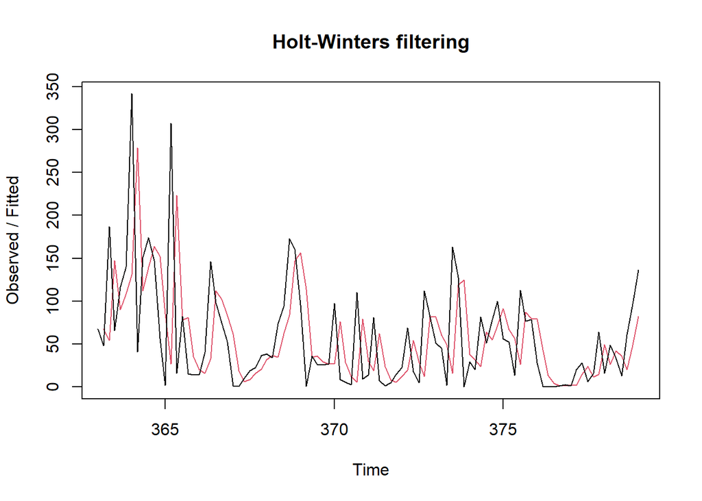

```r
ses2<- HoltWinters(train.ts, gamma = FALSE, beta = FALSE, alpha = 0.7)
plot(ses2)
```

```r
#ramalan
ramalan2<- forecast(ses2, h=24)
ramalan2
```

```
##          Point Forecast       Lo 80    Hi 80      Lo 95    Hi 95
## 379.1667       120.1289   32.824808 207.4330  -13.39118 253.6490
## 379.3333       120.1289   13.560677 226.6971  -42.85313 283.1109
## 379.5000       120.1289   -2.718843 242.9766  -67.75050 308.0083
## 379.6667       120.1289  -17.080246 257.3380  -89.71437 329.9722
## 379.8333       120.1289  -30.074733 270.3325 -109.58773 349.8455
## 380.0000       120.1289  -42.031246 282.2890 -127.87364 368.1314
## 380.1667       120.1289  -53.164765 293.4225 -144.90089 385.1587
## 380.3333       120.1289  -63.624946 303.8827 -160.89835 401.1561
## 380.5000       120.1289  -73.520933 313.7787 -176.03296 416.2907
## 380.6667       120.1289  -82.935226 323.1930 -190.43088 430.6887
## 380.8333       120.1289  -91.931989 332.1898 -204.19024 444.4480
## 381.0000       120.1289 -100.562292 340.8201 -217.38915 457.6469
## 381.1667       120.1289 -108.867571 349.1254 -230.09098 470.3488
## 381.3333       120.1289 -116.881997 357.1398 -242.34798 482.6058
## 381.5000       120.1289 -124.634143 364.8919 -254.20387 494.4616
## 381.6667       120.1289 -132.148187 372.4060 -265.69560 505.9534
## 381.8333       120.1289 -139.444808 379.7026 -276.85482 517.1126
## 382.0000       120.1289 -146.541855 386.7996 -287.70882 527.9666
## 382.1667       120.1289 -153.454859 393.7126 -298.28135 538.5391
## 382.3333       120.1289 -160.197436 400.4552 -308.59323 548.8510
## 382.5000       120.1289 -166.781602 407.0394 -318.66284 558.9206
## 382.6667       120.1289 -173.218024 413.4758 -328.50650 568.7643
## 382.8333       120.1289 -179.516222 419.7740 -338.13876 578.3965
## 383.0000       120.1289 -185.684737 425.9425 -347.57269 587.8305
```

Fungsi `HoltWinters` memiliki argumen yang sama dengan fungsi `ses()` . Argumen-argumen kedua fungsi dapat dilihat lebih lanjut dengan `?ses()` atau `?HoltWinters` .

Nilai parameter $\alpha$ dari kedua fungsi dapat dioptimalkan menyesuaikan dari *error*-nya paling minimumnya. Caranya adalah dengan membuat parameter $\alpha =$ `NULL` .

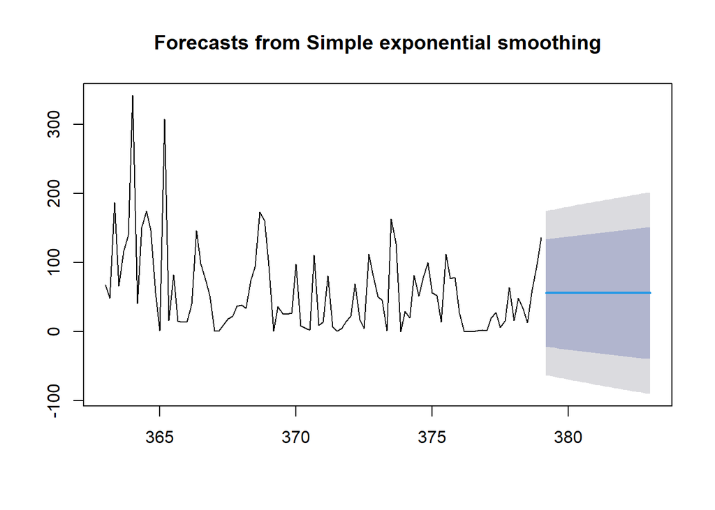

```r
#SES
ses.opt <- ses(train.ts, h = 24, alpha = NULL)
plot(ses.opt)
```

```r
ses.opt
```

```
##          Point Forecast     Lo 80    Hi 80     Lo 95    Hi 95
## 379.1667       55.94651 -21.52470 133.4177 -62.53548 174.4285
## 379.3333       55.94651 -22.38496 134.2780 -63.85113 175.7442
## 379.5000       55.94651 -23.23587 135.1289 -65.15249 177.0455
## 379.6667       55.94651 -24.07773 135.9708 -66.44001 178.3330
## 379.8333       55.94651 -24.91083 136.8039 -67.71413 179.6072
## 380.0000       55.94651 -25.73544 137.6285 -68.97525 180.8683
## 380.1667       55.94651 -26.55180 138.4448 -70.22377 182.1168
## 380.3333       55.94651 -27.36016 139.2532 -71.46005 183.3531
## 380.5000       55.94651 -28.16075 140.0538 -72.68445 184.5775
## 380.6667       55.94651 -28.95380 140.8468 -73.89731 185.7903
## 380.8333       55.94651 -29.73950 141.6325 -75.09894 186.9920
## 381.0000       55.94651 -30.51807 142.4111 -76.28965 188.1827
## 381.1667       55.94651 -31.28968 143.1827 -77.46974 189.3628
## 381.3333       55.94651 -32.05454 143.9476 -78.63948 190.5325
## 381.5000       55.94651 -32.81280 144.7058 -79.79914 191.6922
## 381.6667       55.94651 -33.56463 145.4577 -80.94897 192.8420
## 381.8333       55.94651 -34.31021 146.2032 -82.08923 193.9823
## 382.0000       55.94651 -35.04968 146.9427 -83.22015 195.1132
## 382.1667       55.94651 -35.78318 147.6762 -84.34195 196.2350
## 382.3333       55.94651 -36.51087 148.4039 -85.45485 197.3479
## 382.5000       55.94651 -37.23287 149.1259 -86.55906 198.4521
## 382.6667       55.94651 -37.94932 149.8424 -87.65478 199.5478
## 382.8333       55.94651 -38.66035 150.5534 -88.74220 200.6352
## 383.0000       55.94651 -39.36607 151.2591 -89.82151 201.7145
```

```r
#Lamda Optimum Holt Winter
sesopt<- HoltWinters(train.ts, gamma = FALSE, beta = FALSE,alpha = NULL)
sesopt
```

```
## Holt-Winters exponential smoothing without trend and without seasonal component.
##
## Call:
## HoltWinters(x = train.ts, alpha = NULL, beta = FALSE, gamma = FALSE)
##
## Smoothing parameters:
##  alpha: 0.1858186
##  beta : FALSE
##  gamma: FALSE
##
## Coefficients:
##       [,1]
## a 61.85261
```

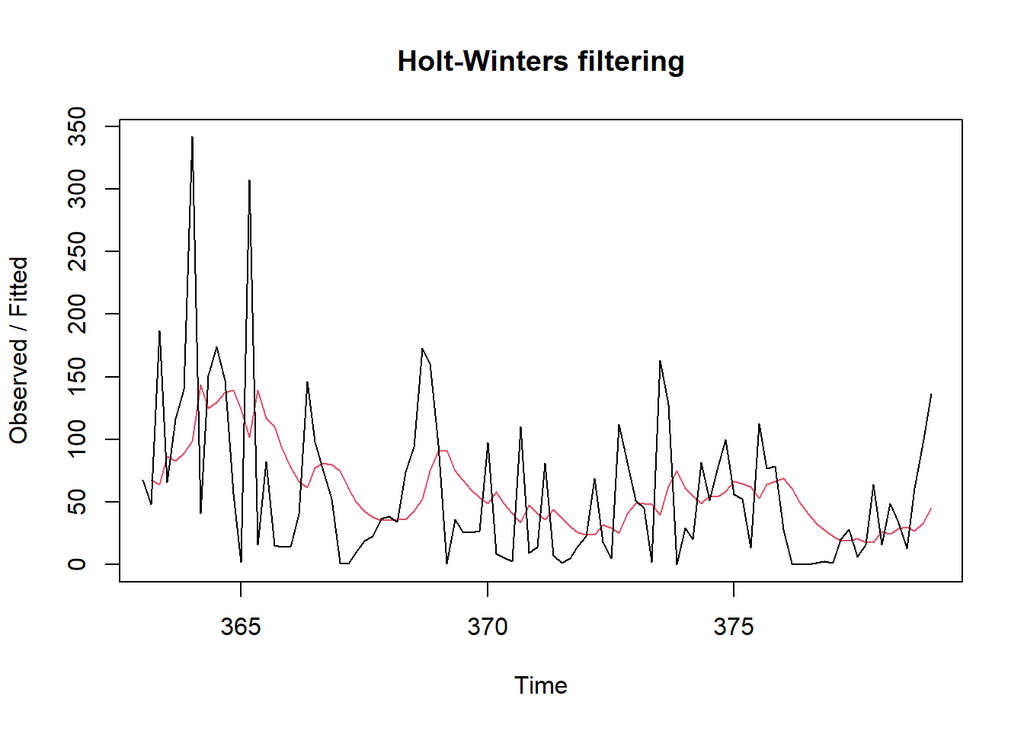

```r
plot(sesopt)
```

```r
#ramalan
ramalanopt<- forecast(sesopt, h=24)
ramalanopt
```

```
##          Point Forecast     Lo 80    Hi 80     Lo 95    Hi 95
## 379.1667       61.85261 -16.29448 139.9997 -57.66305 181.3683
## 379.3333       61.85261 -17.63218 141.3374 -59.70889 183.4141
## 379.5000       61.85261 -18.94774 142.6530 -61.72087 185.4261
## 379.6667       61.85261 -20.24222 143.9474 -63.70061 187.4058
## 379.8333       61.85261 -21.51661 145.2218 -65.64961 189.3548
## 380.0000       61.85261 -22.77180 146.4770 -67.56926 191.2745
## 380.1667       61.85261 -24.00865 147.7139 -69.46086 193.1661
## 380.3333       61.85261 -25.22793 148.9332 -71.32559 195.0308
## 380.5000       61.85261 -26.43037 150.1356 -73.16456 196.8698
## 380.6667       61.85261 -27.61666 151.3219 -74.97883 198.6841
## 380.8333       61.85261 -28.78742 152.4926 -76.76935 200.4746
## 381.0000       61.85261 -29.94325 153.6485 -78.53704 202.2423
## 381.1667       61.85261 -31.08470 154.7899 -80.28274 203.9880
## 381.3333       61.85261 -32.21231 155.9175 -82.00727 205.7125
## 381.5000       61.85261 -33.32655 157.0318 -83.71136 207.4166
## 381.6667       61.85261 -34.42791 158.1331 -85.39573 209.1010
## 381.8333       61.85261 -35.51680 159.2220 -87.06106 210.7663
## 382.0000       61.85261 -36.59366 160.2989 -88.70796 212.4132
## 382.1667       61.85261 -37.65886 161.3641 -90.33704 214.0423
## 382.3333       61.85261 -38.71277 162.4180 -91.94887 215.6541
## 382.5000       61.85261 -39.75576 163.4610 -93.54399 217.2492
## 382.6667       61.85261 -40.78815 164.4934 -95.12289 218.8281
## 382.8333       61.85261 -41.81026 165.5155 -96.68607 220.3913
## 383.0000       61.85261 -42.82239 166.5276 -98.23399 221.9392
```

Setelah dilakukan peramalan, akan dilakukan perhitungan keakuratan hasil peramalan. Perhitungan akurasi ini dilakukan baik pada data latih dan data uji.

#### Akurasi Data Latih

Perhitungan akurasi data dapat dilakukan dengan cara langsung maupun manual. Secara langsung, nilai akurasi dapat diambil dari objek yang tersimpan pada hasil SES, yaitu *sum of squared errors* (SSE). Nilai akurasi lain dapat dihitung pula dari nilai SSE tersebut.

```r
#Keakuratan Metode
#Pada data training
SSE1<-ses1$SSE
MSE1<-ses1$SSE/length(train.ts)
RMSE1<-sqrt(MSE1)

akurasi1 <- matrix(c(SSE1,MSE1,RMSE1))
row.names(akurasi1)<- c("SSE", "MSE", "RMSE")
colnames(akurasi1) <- c("Akurasi lamda=0.2")
akurasi1
```

```
##      Akurasi lamda=0.2
## SSE       353346.34252
## MSE         3642.74580
## RMSE          60.35516
```

```r
SSE2<-ses2$SSE
MSE2<-ses2$SSE/length(train.ts)
RMSE2<-sqrt(MSE2)

akurasi2 <- matrix(c(SSE2,MSE2,RMSE2))
row.names(akurasi2)<- c("SSE", "MSE", "RMSE")
colnames(akurasi2) <- c("Akurasi lamda=0.7")
akurasi2
```

```
##      Akurasi lamda=0.7
## SSE       440939.24342
## MSE         4545.76540
## RMSE          67.42229
```

```r
#Cara Manual
fitted1<-ramalan1$fitted
sisaan1<-ramalan1$residuals
head(sisaan1)
```

```
## Time Series:
## Start = c(363, 1)
## End = c(363, 6)
## Frequency = 6
## [1]        NA -19.10540 123.45348 -22.33892  32.43887  49.97999
```

```r
resid1<-training$`Akumulasi Hujan`-ramalan1$fitted
head(resid1)
```

```
## Time Series:
## Start = c(363, 1)
## End = c(363, 6)
## Frequency = 6
## [1]        NA -19.10540 123.45348 -22.33892  32.43887  49.97999
```

```r
#Cara Manual
SSE.1=sum(sisaan1[2:length(train.ts)]^2)
SSE.1
```

```
## [1] 353346.3
```

```r
MSE.1 = SSE.1/length(train.ts)
MSE.1
```

```
## [1] 3642.746
```

```r
MAPE.1 = sum(abs(sisaan1[2:length(train.ts)]/train.ts[2:length(train.ts)])*
               100)/length(train.ts)
MAPE.1
```

```
## [1] 1966.989
```

```r
akurasi.1 <- matrix(c(SSE.1,MSE.1,MAPE.1))
row.names(akurasi.1)<- c("SSE", "MSE", "MAPE")
colnames(akurasi.1) <- c("Akurasi lamda=0.2")
akurasi.1
```

```
##      Akurasi lamda=0.2
## SSE         353346.343
## MSE           3642.746
## MAPE          1966.989
```

```r
fitted2<-ramalan2$fitted
sisaan2<-ramalan2$residuals
head(sisaan2)
```

```
## Time Series:
## Start = c(363, 1)
## End = c(363, 6)
## Frequency = 6
## [1]        NA -19.10540 133.00618 -81.19985  25.95005  31.81391
```

```r
resid2<-training$`Akumulasi Hujan`-ramalan2$fitted
head(resid2)
```

```
## Time Series:
## Start = c(363, 1)
## End = c(363, 6)
## Frequency = 6
## [1]        NA -19.10540 133.00618 -81.19985  25.95005  31.81391
```

```r
SSE.2=sum(sisaan2[2:length(train.ts)]^2)
SSE.2
```

```
## [1] 440939.2
```

```r
MSE.2 = SSE.2/length(train.ts)
MSE.2
```

```
## [1] 4545.765
```

```r
MAPE.2 = sum(abs(sisaan2[2:length(train.ts)]/train.ts[2:length(train.ts)])*
               100)/length(train.ts)
MAPE.2
```

```
## [1] 1127.824
```

```r
akurasi.2 <- matrix(c(SSE.2,MSE.2,MAPE.2))
row.names(akurasi.2)<- c("SSE", "MSE", "MAPE")
colnames(akurasi.2) <- c("Akurasi lamda=0.7")
akurasi.2
```

```
##      Akurasi lamda=0.7
## SSE         440939.243
## MSE           4545.765
## MAPE          1127.824
```

akan tetapi jika dilihat dari nilai mape nya, pada lamda 0,7 lebih kecil dari pada 0,2 namun hal ini masih akurasinya tidak baik karena nilai kedua lamda lebih dari 10% yang berarti masih ada faktor yang mempengaruhi akurasi model secara negatif.

#### Akurasi Data Uji

Akurasi data uji dapat dihitung dengan cara yang hampir sama dengan perhitungan akurasi data latih.

```r
selisih1<-ramalan1$mean-testing$`Akumulasi Hujan`
SSEtesting1<-sum(selisih1^2)
MSEtesting1<-SSEtesting1/length(testing)

selisih2<-ramalan2$mean-testing$`Akumulasi Hujan`
SSEtesting2<-sum(selisih2^2)
MSEtesting2<-SSEtesting2/length(testing)

selisihopt<-ramalanopt$mean-testing$`Akumulasi Hujan`
SSEtestingopt<-sum(selisihopt^2)
MSEtestingopt<-SSEtestingopt/length(testing)

akurasitesting1 <- matrix(c(SSEtesting1,SSEtesting2,SSEtestingopt))
row.names(akurasitesting1)<- c("SSE1", "SSE2", "SSEopt")
akurasitesting1
```

```
##             [,1]
## SSE1    85365.33
## SSE2   151251.25
## SSEopt  85877.17
```

```r
akurasitesting2 <- matrix(c(MSEtesting1,MSEtesting2,MSEtestingopt))
row.names(akurasitesting2)<- c("MSE1", "MSE2", "MSEopt")
akurasitesting2
```

```
##            [,1]
## MSE1   42682.67
## MSE2   75625.63
## MSEopt 42938.58
```

Selain dengan cara di atas, perhitungan nilai akurasi dapat menggunakan fungsi `accuracy()` dari *package* `forecast` . Penggunaannya yaitu dengan menuliskan `accuracy(hasil ramalan, kondisi aktual)` . Contohnya adalah sebagai berikut.

```r
#cara lain
accuracy(ramalanopt,testing$`Akumulasi Hujan`)
```

```
##                     ME     RMSE      MAE       MPE     MAPE      MASE
## Training set -0.311162 60.66087 44.89843 -1982.458 2018.016 0.9379895
## Test set      5.767392 59.81818 49.84894 -1821.260 1860.059 1.0414124
##                    ACF1
## Training set 0.02719903
## Test set             NA
```

### DES

Metode pemulusan *Double Exponential Smoothing* (DES) digunakan untuk data yang memiliki pola tren. Metode DES adalah metode semacam SES, hanya saja dilakukan dua kali, yaitu pertama untuk tahapan ‘level’ dan kedua untuk tahapan ‘tren’. Pemulusan menggunakan metode ini akan menghasilkan peramalan tidak konstan untuk periode berikutnya.

Pemulusan dengan metode DES kali ini akan menggunakan fungsi `HoltWinters()` . Jika sebelumnya nilai argumen `beta` dibuat `FALSE` , kali ini argumen tersebut akan diinisialisasi bersamaan dengan nilai `alpha` .

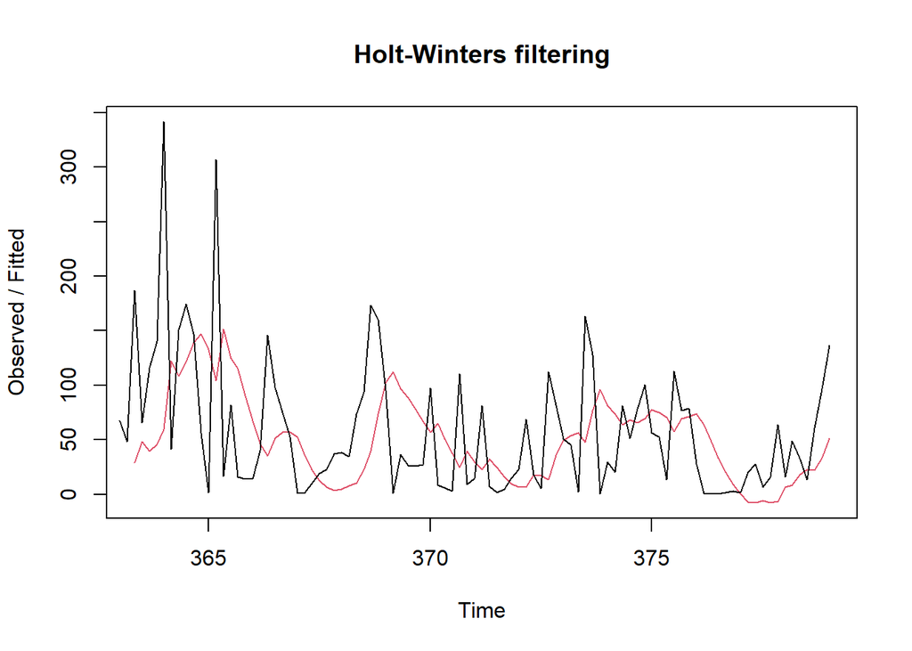

```r
#Lamda=0.2 dan gamma=0.2
des.1<- HoltWinters(train.ts, gamma = FALSE, beta = 0.2, alpha = 0.2)
plot(des.1)
```

```r
#ramalan
ramalandes1<- forecast(des.1, h=24)
ramalandes1
```

```
##          Point Forecast      Lo 80    Hi 80      Lo 95    Hi 95
## 379.1667       77.41106  -8.719900 163.5420  -54.31488 209.1370
## 379.3333       86.41277  -2.164037 174.9896  -49.05377 221.8793
## 379.5000       95.41448   3.613254 187.2157  -44.98338 235.8123
## 379.6667      104.41619   8.566702 200.2657  -42.17295 251.0053
## 379.8333      113.41789  12.677798 214.1580  -40.65079 267.4866
## 380.0000      122.41960  15.951137 228.8881  -40.40986 285.2491
## 380.1667      131.42131  18.409080 244.4335  -41.41598 304.2586
## 380.3333      140.42301  20.086006 260.7600  -43.61656 324.4626
## 380.5000      149.42472  21.023126 277.8263  -46.94857 345.7980
## 380.6667      158.42643  21.264391 295.5885  -51.34481 368.1977
## 380.8333      167.42814  20.853581 314.0027  -56.73830 391.5946
## 381.0000      176.42984  19.832476 333.0272  -63.06516 415.9249
## 381.1667      185.43155  18.239836 352.6233  -70.26611 441.1292
## 381.3333      194.43326  16.110959 372.7556  -78.28716 467.1537
## 381.5000      203.43497  13.477621 393.3923  -87.07972 493.9497
## 381.6667      212.43667  10.368218 414.5051  -96.60036 521.4737
## 381.8333      221.43838   6.808037 436.0687 -106.81040 549.6872
## 382.0000      230.44009   2.819561 458.0606 -117.67547 578.5556
## 382.1667      239.44179  -1.577206 480.4608 -129.16496 608.0485
## 382.3333      248.44350  -6.364441 503.2514 -141.25162 638.1386
## 382.5000      257.44521 -11.526222 526.4166 -153.91110 668.8015
## 382.6667      266.44692 -17.048281 549.9421 -167.12157 700.0154
## 382.8333      275.44862 -22.917787 573.8150 -180.86342 731.7607
## 383.0000      284.45033 -29.123162 598.0238 -195.11894 764.0196
```

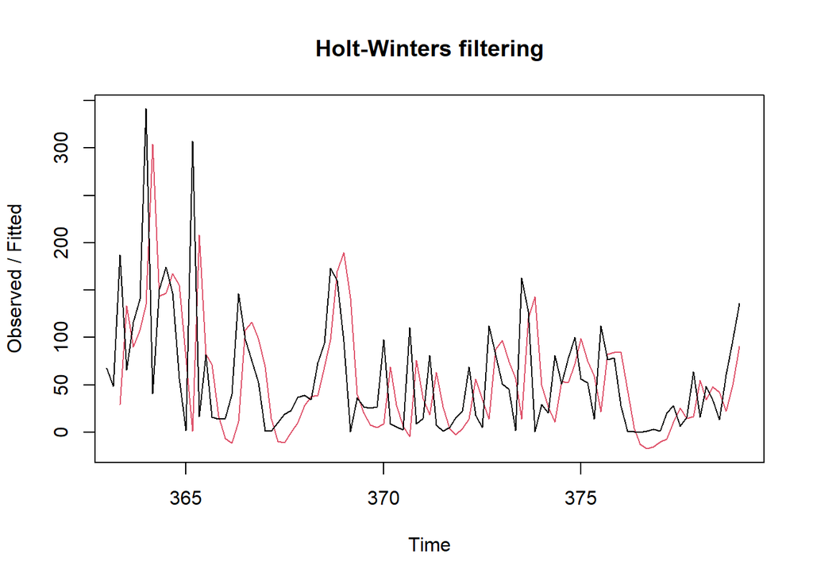

```r
#Lamda=0.6 dan gamma=0.3
des.2<- HoltWinters(train.ts, gamma = FALSE, beta = 0.3, alpha = 0.6)
plot(des.2)
```

```r
#ramalan
ramalandes2<- forecast(des.2, h=24)
ramalandes2
```

```
##          Point Forecast       Lo 80     Hi 80        Lo 95     Hi 95
## 379.1667       139.2062   45.432998  232.9794    -4.207542  282.6200
## 379.3333       160.2714   41.345639  279.1971   -21.609840  342.1526
## 379.5000       181.3365   32.181101  330.4920   -46.777011  409.4501
## 379.6667       202.4017   18.893474  385.9099   -78.249905  483.0533
## 379.8333       223.4668    2.114385  444.8193  -115.062528  561.9962
## 380.0000       244.5320  -17.731407  506.7954  -156.565269  645.6293
## 380.1667       265.5972  -40.345043  571.5394  -202.301061  733.4954
## 380.3333       286.6623  -65.505726  638.8304  -251.932227  825.2569
## 380.5000       307.7275  -93.043043  708.4980  -305.198140  920.6531
## 380.6667       328.7926 -122.820561  780.4058  -361.890144 1019.4754
## 380.8333       349.8578 -154.725750  854.4413  -421.836141 1121.5517
## 381.0000       370.9229 -188.663541  930.5094  -484.890735 1226.7366
## 381.1667       391.9881 -224.552046 1008.5283  -550.928689 1334.9049
## 381.3333       413.0533 -262.319614 1088.4261  -619.840420 1445.9470
## 381.5000       434.1184 -301.902738 1170.1396  -691.528805 1559.7657
## 381.6667       455.1836 -343.244526 1253.6117  -765.906835 1676.2740
## 381.8333       476.2487 -386.293562 1338.7910  -842.895874 1795.3934
## 382.0000       497.3139 -431.003019 1425.6308  -922.424309 1917.0521
## 382.1667       518.3791 -477.329980 1514.0881 -1004.426503 2041.1846
## 382.3333       539.4442 -525.234890 1604.1233 -1088.841962 2167.7304
## 382.5000       560.5094 -574.681115 1695.6999 -1175.614659 2296.6334
## 382.6667       581.5745 -625.634582 1788.7836 -1264.692483 2427.8415
## 382.8333       602.6397 -678.063479 1883.3429 -1356.026783 2561.3062
## 383.0000       623.7048 -731.938006 1979.3477 -1449.571983 2696.9817
```

Selanjutnya jika ingin membandingkan plot data latih dan data uji adalah sebagai berikut.

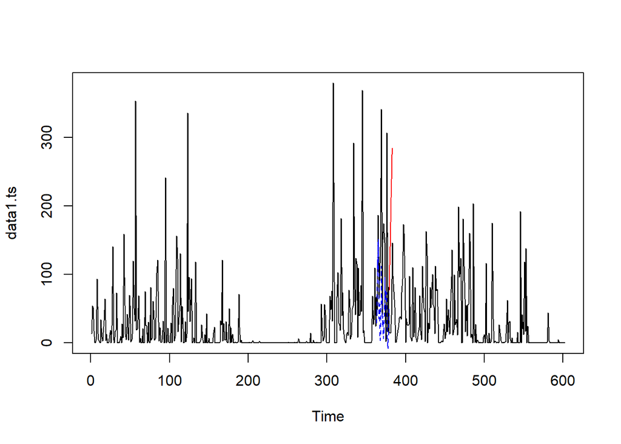

```r
#Visually evaluate the prediction
plot(data1.ts)
lines(des.1$fitted[,1], lty=2, col="blue")
lines(ramalandes1$mean, col="red")
```

Untuk mendapatkan nilai parameter optimum dari DES, argumen `alpha` dan `beta` dapat dibuat `NULL` seperti berikut.

```r
#Lamda dan gamma optimum
des.opt<- HoltWinters(train.ts, gamma = FALSE)
des.opt
```

```
## Holt-Winters exponential smoothing with trend and without seasonal component.
##
## Call:
## HoltWinters(x = train.ts, gamma = FALSE)
##
## Smoothing parameters:
##  alpha: 0.3292179
##  beta : 0.07439258
##  gamma: FALSE
##
## Coefficients:
##       [,1]
## a 84.16920
## b  3.74999
```

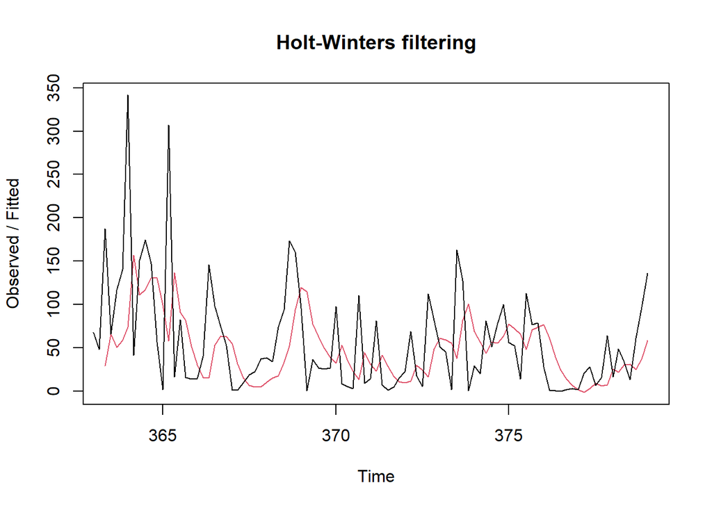

```r
plot(des.opt)
```

```r
#ramalan
ramalandesopt<- forecast(des.opt, h=24)
ramalandesopt
```

```
##          Point Forecast       Lo 80    Hi 80      Lo 95    Hi 95
## 379.1667       87.91919   5.1251520 170.7132  -38.70337 214.5418
## 379.3333       91.66918   3.8485393 179.4898  -42.64090 225.9793
## 379.5000       95.41917   2.1831597 188.6552  -47.17300 238.0114
## 379.6667       99.16916   0.1512715 198.1871  -52.26563 250.6040
## 379.8333      102.91915  -2.2257702 208.0641  -57.88613 263.7244
## 380.0000      106.66914  -4.9279616 218.2663  -64.00390 277.3422
## 380.1667      110.41914  -7.9368678 228.7751  -70.59075 291.4290
## 380.3333      114.16913 -11.2356849 239.5739  -77.62098 305.9592
## 380.5000      117.91912 -14.8092034 250.6474  -85.07133 320.9096
## 380.6667      121.66911 -18.6437145 261.9819  -92.92084 336.2590
## 380.8333      125.41910 -22.7268878 273.5651 -101.15063 351.9888
## 381.0000      129.16909 -27.0476385 285.3858 -109.74378 368.0820
## 381.1667      132.91908 -31.5959947 297.4341 -118.68501 384.5232
## 381.3333      136.66907 -36.3629728 309.7011 -127.96060 401.2987
## 381.5000      140.41906 -41.3404619 322.1786 -137.55814 418.3963
## 381.6667      144.16905 -46.5211204 334.8592 -147.46640 435.8045
## 381.8333      147.91904 -51.8982847 347.7364 -157.67519 453.5133
## 382.0000      151.66903 -57.4658874 360.8039 -168.17522 471.5133
## 382.1667      155.41902 -63.2183872 374.0564 -178.95804 489.7961
## 382.3333      159.16901 -69.1507069 387.4887 -190.01586 508.3539
## 382.5000      162.91900 -75.2581801 401.0962 -201.34156 527.1796
## 382.6667      166.66899 -81.5365038 414.8745 -212.92856 546.2665
## 382.8333      170.41898 -87.9816987 428.8197 -224.77076 565.6087
## 383.0000      174.16897 -94.5900733 442.9280 -236.86252 585.2005
```

Selanjutnya akan dilakukan perhitungan akurasi pada data latih maupun data uji dengan ukuran akurasi SSE, MSE dan MAPE.

#### Akurasi Data Latih

```r
#Akurasi Data Training
ssedes.train1<-des.1$SSE
msedes.train1<-ssedes.train1/length(train.ts)
sisaandes1<-ramalandes1$residuals
head(sisaandes1)
```

```
## Time Series:
## Start = c(363, 1)
## End = c(363, 6)
## Frequency = 6
## [1]        NA        NA 157.84320  17.96453  76.75472  94.43558
```

```r
mapedes.train1 <- sum(abs(sisaandes1[3:length(train.ts)]/train.ts[3:length(train.ts)])
                      *100)/length(train.ts)

akurasides.1 <- matrix(c(ssedes.train1,msedes.train1,mapedes.train1))
row.names(akurasides.1)<- c("SSE", "MSE", "MAPE")
colnames(akurasides.1) <- c("Akurasi lamda=0.2 dan gamma=0.2")
akurasides.1
```

```
##      Akurasi lamda=0.2 dan gamma=0.2
## SSE                       429791.865
## MSE                         4430.844
## MAPE                        1860.387
```

```r
ssedes.train2<-des.2$SSE
msedes.train2<-ssedes.train2/length(train.ts)
sisaandes2<-ramalandes2$residuals
head(sisaandes2)
```

```
## Time Series:
## Start = c(363, 1)
## End = c(363, 6)
## Frequency = 6
## [1]        NA        NA 157.84320 -67.27080  26.20405  32.59616
```

```r
mapedes.train2 <- sum(abs(sisaandes2[3:length(train.ts)]/train.ts[3:length(train.ts)])
                      *100)/length(train.ts)

akurasides.2 <- matrix(c(ssedes.train2,msedes.train2,mapedes.train2))
row.names(akurasides.2)<- c("SSE", "MSE", "MAPE")
colnames(akurasides.2) <- c("Akurasi lamda=0.6 dan gamma=0.3")
akurasides.2
```

```
##      Akurasi lamda=0.6 dan gamma=0.3
## SSE                       503808.432
## MSE                         5193.901
## MAPE                        1458.646
```

#### Akurasi Data Uji

```r
#Akurasi Data Testing
selisihdes1<-ramalandes1$mean-testing$`Akumulasi Hujan`
selisihdes1
```

```
## Time Series:
## Start = c(379, 2)
## End = c(383, 1)
## Frequency = 6
##  [1]  65.897164  67.380371  -3.863621  77.589286  82.578893  87.568500
##  [7] 120.029608 -58.166585  53.273122  57.942529  43.518237 176.161944
## [13] 185.095351  13.072058  90.756866 148.004973 205.253080 175.276987
## [19] 228.993895 193.173902 200.650709 106.132316 126.725224 276.411831
```

```r
SSEtestingdes1<-sum(selisihdes1^2)
MSEtestingdes1<-SSEtestingdes1/length(testing$`Akumulasi Hujan`)
MAPEtestingdes1<-sum(abs(selisihdes1/testing$`Akumulasi Hujan`)*100)/length(testing$`Akumulasi Hujan`)

selisihdes2<-ramalandes2$mean-testing$`Akumulasi Hujan`
selisihdes2
```

```
## Time Series:
## Start = c(379, 2)
## End = c(383, 1)
## Frequency = 6
##  [1] 127.69231 141.23897  82.05843 175.57479 192.62784 209.68090 254.20546
##  [8]  88.07272 211.57588 228.30873 225.94789 370.65505 391.65191 231.69207
## [15] 321.44032 390.75188 460.06344 442.15080 507.93116 484.17461 503.71487
## [22] 421.25993 453.91629 615.66635
```

```r
SSEtestingdes2<-sum(selisihdes2^2)
MSEtestingdes2<-SSEtestingdes2/length(testing$`Akumulasi Hujan`)
MAPEtestingdes2<-sum(abs(selisihdes2/testing$`Akumulasi Hujan`)*100)/length(testing$`Akumulasi Hujan`)

selisihdesopt<-ramalandesopt$mean-testing$`Akumulasi Hujan`
selisihdesopt
```

```
## Time Series:
## Start = c(379, 2)
## End = c(383, 1)
## Frequency = 6
##  [1]  76.405293  72.636783  -3.858926  72.342264  72.080154  71.818045
##  [7]  99.027435 -84.420475  21.767516  21.185206   1.509197 128.901187
## [13] 132.582877 -44.692132  27.740958  79.737348 131.733739  96.505929
## [19] 144.971119 103.899410 106.124500   6.354390  21.695581 166.130471
```

```r
SSEtestingdesopt<-sum(selisihdesopt^2)
MSEtestingdesopt<-SSEtestingdesopt/length(testing$`Akumulasi Hujan`)
MAPEtestingdesopt<-sum(abs(selisihdesopt/testing$`Akumulasi Hujan`)*100)/length(testing$`Akumulasi Hujan`)

akurasitestingdes <-
  matrix(c(SSEtestingdes1,MSEtestingdes1,MAPEtestingdes1,SSEtestingdes2,MSEtestingdes2,
           MAPEtestingdes2,SSEtestingdesopt,MSEtestingdesopt,MAPEtestingdesopt),
         nrow=3,ncol=3)
row.names(akurasitestingdes)<- c("SSE", "MSE", "MAPE")
colnames(akurasitestingdes) <- c("des ske1","des ske2","des opt")
akurasitestingdes
```

```
##        des ske1   des ske2    des opt
## SSE  457483.995 2891521.29 185744.143
## MSE   19061.833  120480.05   7739.339
## MAPE   5507.055   11711.85   3969.832
```

#### Perbandingan SES dan DES

```r
MSEfull <-
  matrix(c(MSEtesting1,MSEtesting2,MSEtestingopt,MSEtestingdes1,MSEtestingdes2,
           MSEtestingdesopt),nrow=3,ncol=2)
row.names(MSEfull)<- c("ske 1", "ske 2", "ske opt")
colnames(MSEfull) <- c("ses","des")
MSEfull
```

```
##              ses        des
## ske 1   42682.67  19061.833
## ske 2   75625.63 120480.054
## ske opt 42938.58   7739.339
```

## Pemulusan Data Musiman

Pertama impor kembali data baru untuk latihan data musiman.

```r
#Import data
library(rio)
data3 <- import("C:/Users/Irsyad Parama/Downloads/data hujan bogor.xlsx")
data3.ts <- ts(data3$`Akumulasi Hujan`)
```

Selanjutnya melakukan pembagian data dan mengubahnya menjadi data deret waktu.

```r
#membagi data menjadi training dan testing
training<-data3[363:459,2]
testing<-data3[460:483,2]
training.ts<-ts(training, frequency = 6)
testing.ts<-ts(testing, frequency = 6)
```

Kemudian akan dilakukan eskplorasi dengan plot data deret waktu sebagai berikut.

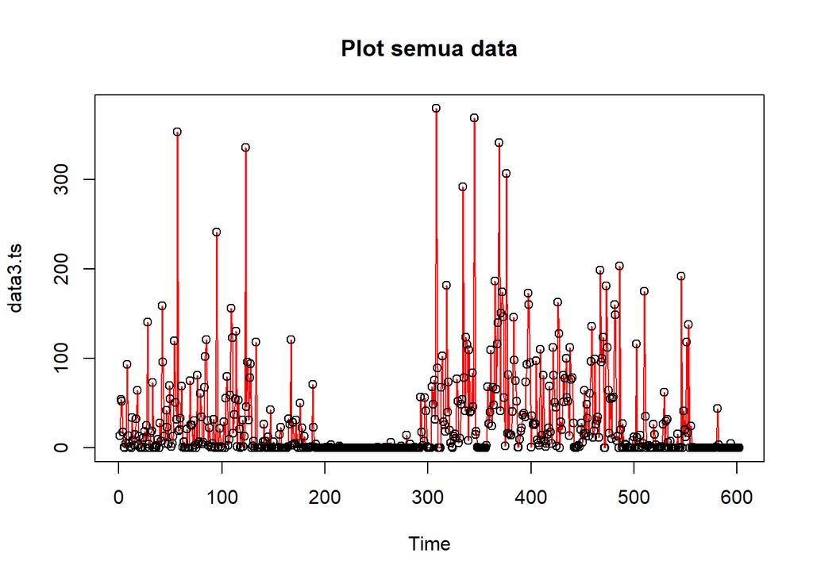

```r
#Membuat plot time series
plot(data3.ts, col="red",main="Plot semua data")
points(data3.ts)
```

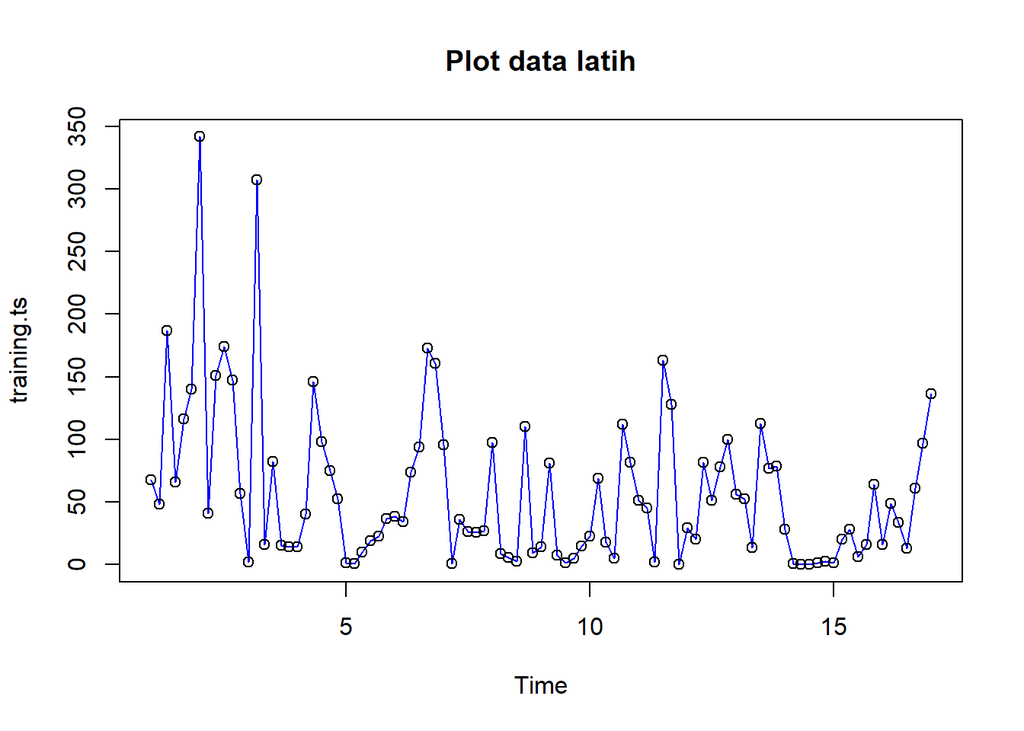

```r
plot(training.ts, col="blue",main="Plot data latih")
points(training.ts)
```

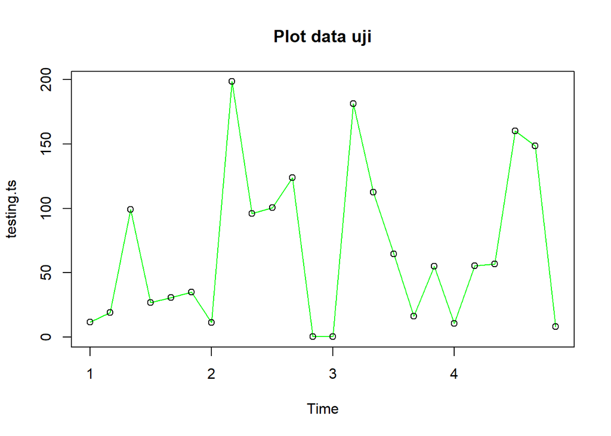

```r
plot(testing.ts, col="green",main="Plot data uji")
points(testing.ts)
```

Pemulusan data musiman dengan metode Winter dilakukan menggunakan fungsi `HoltWinters()` dengan memasukkan argumen tambahan, yaitu `gamma()` dan `seasonal()` . Arguman `seasonal()` diinisialisasi menyesuaikan jenis musiman, aditif atau multiplikatif.

### Winter Aditif

Perhitungan dengan model aditif dilakukan jika plot data asli menunjukkan fluktuasi musiman yang relatif stabil (konstan).

#### Pemulusan

```r
#Pemulusan dengan winter aditif
winter1 <- HoltWinters(training.ts,alpha=0.2,beta=0.1,gamma=0.1,seasonal = "additive")
winter1$fitted
```

```
## Time Series:
## Start = c(2, 1)
## End = c(17, 1)
## Frequency = 6
##                  xhat      level       trend        season
##  2.000000 331.0416063 128.596854  5.92180524  196.52294722
##  2.166667  27.1784762 136.629718  6.13291111 -115.58415278
##  2.333333 150.6848959 145.543334  6.41098159   -1.26941944
##  2.500000 103.9552000 152.014116  6.41696167  -54.47587778
##  2.666667 153.8977100 172.488978  7.82275167  -26.41401944
##  2.833333 187.8462412 178.940127  7.68559147    1.22052222
##  3.000000 362.7876121 160.361111  5.05913065  197.36737071
##  3.166667 -23.3951215  93.236039 -2.15928960 -114.47187087
##  3.333333 160.4059674 157.198574  4.45289283   -1.24549911
##  3.500000  85.5294967 132.813153  1.56906149  -48.85271778
##  3.666667 108.2146345 133.678595  1.49869955  -26.96266025
##  3.833333 107.0173236 116.656068 -0.35342314   -9.28532107
##  4.000000 264.0080081  97.725460 -2.21114161  168.49368975
##  4.166667 -49.6539002  45.574377 -7.20513577  -88.02314115
##  4.333333  38.1908487  56.376121 -5.40444777  -12.78082450
##  4.500000  20.1413272  72.524643 -3.24915074  -49.13416552
##  4.666667  48.8091130  84.869967 -1.68970329  -34.37115100
##  4.833333  70.5783589  88.456621 -1.16206755  -16.71619496
##  5.000000 230.6219425  83.632502 -1.52827272  148.51771310
##  5.166667 -50.7370598  36.201841 -6.11851157  -80.82038914
##  5.333333  31.1904805  40.433601 -5.08348438   -4.15963640
##  5.500000 -17.3132529  31.092381 -5.50925799  -42.89637570
##  5.666667  -4.2441816  32.803633 -4.78720693  -32.26060804
##  5.833333  10.9507338  33.382363 -4.25061330  -18.18101567
##  6.000000 160.7555324  34.329603 -3.73082797  130.15675770
##  6.166667 -76.6940527   6.160848 -6.17462062  -76.68028035
##  6.333333  12.3644438  22.182198 -3.95502357   -5.86273084
##  6.500000 -12.2450361  30.491706 -2.72857044  -40.00817146
##  6.666667  18.2141154  48.939303 -0.61095372  -30.11423352
##  6.833333  65.6949254  79.309626  2.48717397  -16.10187438
##  7.000000 225.5098733 100.746175  4.38211146  120.38158711
##  7.166667  13.1653594  79.179972  1.78728000  -67.80189213
##  7.333333  79.0503721  78.469760  1.53753081   -0.95691834
##  7.500000  40.5804088  71.437556  0.68055737  -31.53770458
##  7.666667  51.9644961  69.288612  0.39760719  -17.72172275
```

[output cut: 41 more lines]

```
## 14.666667  36.0219638  38.399607 -2.33841170   -0.03923133
## 14.833333  14.5250120  29.140762 -3.03045497  -11.58529536
## 15.000000  71.7912755  23.764445 -3.26504121   51.29187176
## 15.166667 -38.4083169   6.438669 -4.67111472  -40.17587079
## 15.333333  -6.5123674  13.522557 -3.49561438  -16.53931027
## 15.500000  -1.8903664  16.909976 -2.80731104  -15.99303174
## 15.666667  10.3019085  15.751719 -2.64240571   -2.80740443
## 15.833333  -0.8434350  14.212311 -2.53210588  -12.52364032
## 16.000000  69.0908689  24.657652 -1.23436118   45.66757772
## 16.166667 -24.9314686  12.835537 -2.29313656  -35.47386944
## 16.333333  10.6304985  25.239975 -0.82337918  -13.78609688
## 16.500000  13.2859701  28.985836 -0.36645515  -15.33341043
## 16.666667  25.8712388  28.605306 -0.36786256   -2.36620511
## 16.833333  28.2153073  35.217796  0.33017267   -7.33266153
## 17.000000  92.3980841  49.263847  1.70176052   41.43247621
```

```r
xhat1 <- winter1$fitted[,2]

winter1.opt<- HoltWinters(training.ts, alpha= NULL,  beta = NULL, gamma = NULL, seasonal = "additive")
winter1.opt
```

```
## Holt-Winters exponential smoothing with trend and additive seasonal component.
##
## Call:
## HoltWinters(x = training.ts, alpha = NULL, beta = NULL, gamma = NULL,     seasonal = "additive")
##
## Smoothing parameters:
##  alpha: 0.1394391
##  beta : 0.05531644
##  gamma: 0.4320954
##
## Coefficients:
##           [,1]
## a  104.0848935
## b    0.9687475
## s1 -49.3853741
## s2 -58.1213076
## s3 -59.1427179
## s4 -35.8427634
## s5 -14.8636057
## s6 -21.4231888
```

```r
winter1.opt$fitted
```

```
## Time Series:
## Start = c(2, 1)
## End = c(17, 1)
## Frequency = 6
##                 xhat     level        trend       season
##  2.000000 331.041606 128.59685  5.921805238  196.5229472
##  2.166667  26.409548 135.99048  6.003221087 -115.5841528
##  2.333333 148.886588 144.03961  6.116393700   -1.2694194
##  2.500000 102.105147 150.44845  6.132570840  -54.4758778
##  2.666667 146.915080 166.64010  6.689002816  -26.4140194
##  2.833333 181.256963 173.34648  6.689964044    1.2205222
##  3.000000 368.819415 162.64368  5.727858632  200.4478745
##  3.166667   9.973154 117.20398  2.897451835 -110.1282829
##  3.333333 166.249027 161.54842  5.190151270   -0.4895455
##  3.500000 122.199592 145.81788  4.032893416  -27.6511858
##  3.666667 121.602205 144.24697  3.722910965  -26.3676802
##  3.833333  90.934541 133.19022  2.905352709  -45.1610346
##  4.000000 191.697675 125.38622  2.312949208   63.9985084
##  4.166667 104.307931 102.96416  0.944696743    0.3990749
##  4.333333  39.167394  94.99488  0.451607094  -56.2790881
##  4.500000  69.017296 110.33694  1.275294321  -42.5949420
##  4.666667  51.388285 115.66941  1.499722797  -65.7808508
##  4.833333  48.451613 120.48815  1.683318837  -73.7198560
##  5.000000 122.453647 122.70364  1.712756441   -1.9627456
##  5.166667  84.901163 107.49635  0.776799912  -23.3719852
##  5.333333  80.135351  96.57604  0.129757736  -16.5704497
##  5.500000  54.724922  86.91250 -0.411972732  -31.7756056
##  5.666667  23.870564  81.48970 -0.689153953  -56.9299805
##  5.833333   7.621574  80.62136 -0.699066000  -72.3007164
##  6.000000  36.453792  84.01042 -0.472925011  -47.0837067
##  6.166667  28.810526  83.83201 -0.456633751  -54.5648494
##  6.333333  41.038036  84.13884 -0.414401476  -42.6864056
##  6.500000  42.976359  88.27700 -0.162570368  -45.1380671
##  6.666667  37.998686  95.17833  0.228179672  -57.4078244
##  6.833333  54.119357 114.24777  1.270410950  -61.3988225
##  7.000000  86.135855 130.34368  2.090504847  -46.2983312
##  7.166667  83.413229 133.77733  2.164802514  -52.5288992
##  7.333333  95.386201 124.40559  1.526642438  -30.5460323
##  7.500000  92.449104 117.67960  1.070136292  -26.3006351
##  7.666667 102.941909 109.54450  0.560935370   -7.1635283
```

[output cut: 41 more lines]

```
## 14.666667  65.444391  85.11614 -0.824228001  -18.8475196
## 14.833333  36.579832  75.36438 -1.318067074  -37.4664823
## 15.000000   2.099124  69.33549 -1.578653270  -65.6577097
## 15.166667  -9.159418  67.67156 -1.583370121  -75.2476111
## 15.333333 -12.398497  70.20529 -1.355627150  -81.2481577
## 15.500000  26.676515  74.46924 -1.044772290  -46.7479482
## 15.666667  26.734610  70.59084 -1.201518428  -42.6547081
## 15.833333  16.552309  67.86696 -1.285729690  -50.0289243
## 16.000000   6.398885  73.20340 -0.919414909  -65.8851016
## 16.166667   8.531292  73.64397 -0.844185713  -64.2684882
## 16.333333  11.583038  78.38084 -0.535461177  -66.2623441
## 16.500000  26.227197  80.89821 -0.366589415  -54.3044278
## 16.666667  31.535951  78.71730 -0.466951398  -46.7143978
## 16.833333  49.716220  82.32714 -0.241438090  -32.3694770
## 17.000000  26.513544  88.65028  0.121691022  -62.2584229
```

```r
xhat1.opt <- winter1.opt$fitted[,2]
```

#### Peramalan

```r
#Forecast
forecast1 <- predict(winter1, n.ahead = 24)
forecast1.opt <- predict(winter1.opt, n.ahead = 24)
```

#### Plot Deret Waktu

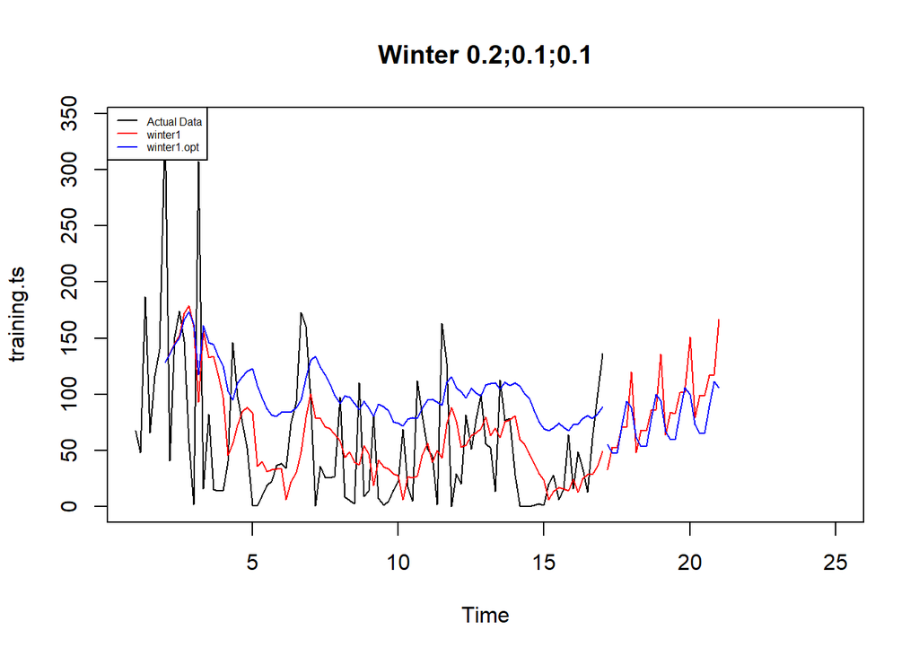

```r
#Plot time series
plot(training.ts,main="Winter 0.2;0.1;0.1",type="l",col="black",
     xlim=c(1,25),pch=12)
lines(xhat1,type="l",col="red")
lines(xhat1.opt,type="l",col="blue")
lines(forecast1,type="l",col="red")
lines(forecast1.opt,type="l",col="blue")
legend("topleft",c("Actual Data",expression(paste(winter1)),
                   expression(paste(winter1.opt))),cex=0.5,
       col=c("black","red","blue"),lty=1)
```

#### Akurasi Data Latih

```r
#Akurasi data training
SSE1<-winter1$SSE
MSE1<-winter1$SSE/length(training.ts)
RMSE1<-sqrt(MSE1)
akurasi1 <- matrix(c(SSE1,MSE1,RMSE1))
row.names(akurasi1)<- c("SSE", "MSE", "RMSE")
colnames(akurasi1) <- c("Akurasi")
akurasi1
```

```
##           Akurasi
## SSE  765876.05152
## MSE    7895.62940
## RMSE     88.85735
```

```r
SSE1.opt<-winter1.opt$SSE
MSE1.opt<-winter1.opt$SSE/length(training.ts)
RMSE1.opt<-sqrt(MSE1.opt)
akurasi1.opt <- matrix(c(SSE1.opt,MSE1.opt,RMSE1.opt))
row.names(akurasi1.opt)<- c("SSE1.opt", "MSE1.opt", "RMSE1.opt")
colnames(akurasi1.opt) <- c("Akurasi")
akurasi1.opt
```

```
##                Akurasi
## SSE1.opt  540748.09187
## MSE1.opt    5574.72260
## RMSE1.opt     74.66406
```

```r
akurasi1.train = data.frame(Model_Winter = c("Winter 1","Winter1 optimal"),
                            Nilai_SSE=c(SSE1,SSE1.opt),
                            Nilai_MSE=c(MSE1,MSE1.opt),Nilai_RMSE=c(RMSE1,RMSE1.opt))
akurasi1.train
```

```
##      Model_Winter Nilai_SSE Nilai_MSE Nilai_RMSE
## 1        Winter 1  765876.1  7895.629   88.85735
## 2 Winter1 optimal  540748.1  5574.723   74.66406
```

#### Akurasi Data Uji

```r
#Akurasi Data Testing
forecast1<-data.frame(forecast1)
testing.ts<-data.frame(testing.ts)
selisih1<-forecast1-testing.ts
SSEtesting1<-sum(selisih1^2)
MSEtesting1<-SSEtesting1/length(testing.ts)

forecast1.opt<-data.frame(forecast1.opt)
selisih1.opt<-forecast1.opt-testing.ts
SSEtesting1.opt<-sum(selisih1.opt^2)
MSEtesting1.opt<-SSEtesting1.opt/length(testing.ts)
```

### Winter Multiplikatif

Model multiplikatif digunakan cocok digunakan jika plot data asli menunjukkan fluktuasi musiman yang bervariasi.

#### Pemulusan

```r
#Pemulusan dengan winter multiplikatif
winter2 <- HoltWinters(training.ts,alpha=0.2,beta=0.1,gamma=0.3,seasonal = "multiplicative")
winter2$fitted
```

```
## Time Series:
## Start = c(2, 1)
## End = c(17, 1)
## Frequency = 6
##                 xhat     level       trend    season
##  2.000000 318.054610 128.59685  5.92180524 2.3643903
##  2.166667  37.678470 136.51006  6.12094571 0.2641674
##  2.333333 151.257106 145.20781  6.37862546 0.9978275
##  2.500000  86.052341 151.53167  6.37314945 0.5449634
##  2.666667 163.425110 190.27117  9.60978391 0.8176122
##  2.833333 207.345753 195.87284  9.20897263 1.0110392
##  3.000000 436.582030 175.24666  6.22545725 2.4057803
##  3.166667  39.914336 145.33287  2.61153260 0.2697928
##  3.333333 367.562822 346.09620 22.42671284 0.9973948
##  3.500000 205.688306 298.06968 15.38138959 0.6562055
##  3.666667 229.186513 275.75650 11.61193283 0.7975354
##  3.833333 193.129341 233.80893  6.25598243 0.8044880
##  4.000000 333.142489 195.56507  1.80599825 1.6878993
##  4.166667  71.741141 159.59226 -1.97188346 0.4551515
##  4.333333 100.379611 143.84006 -3.34991447 0.7144957
##  4.500000  82.928569 153.24770 -2.07415908 0.5485654
##  4.666667  89.746303 156.70985 -1.52052840 0.5783021
##  4.833333  86.630212 150.15548 -2.02391251 0.5848194
##  5.000000 160.939589 136.38021 -3.19904838 1.2084261
##  5.166667  40.638793 106.72864 -5.84430057 0.4028256
##  5.333333  57.682566  81.21106 -7.81162805 0.7858721
##  5.500000  29.855863  61.23950 -9.02762153 0.5718213
##  5.666667  21.605699  48.34124 -9.41468523 0.5550375
##  5.833333  15.678170  39.27961 -9.37937948 0.5243494
##  6.000000  24.996482  38.01003 -8.56840004 0.8490183
##  6.166667   6.968649  32.63812 -8.24875045 0.2857248
##  6.333333  22.253035  43.51067 -6.33662042 0.5986174
##  6.500000  25.709641  54.35834 -4.61819171 0.5168791
##  6.666667  41.534564  76.02334 -1.98987249 0.5610241
##  6.833333  81.431648 120.94266  2.70104631 0.6585992
##  7.000000 144.917200 147.63710  5.10038565 0.9487992
##  7.166667  63.907583 142.37725  4.06436242 0.4364032
##  7.333333  97.954002 117.46397  1.16659779 0.8257063
##  7.500000  75.577185 103.67311 -0.32914720 0.7313169
##  7.666667  72.538560  89.90402 -1.67314152 0.8221448
```

[output cut: 41 more lines]

```
## 14.666667  42.430632  63.68494 -6.19297866 0.7380272
## 14.833333  19.402785  46.37832 -7.30434233 0.4965653
## 15.000000  10.121885  32.38520 -7.97322047 0.4146278
## 15.166667   3.789676  20.24714 -8.38970414 0.3196033
## 15.333333   2.847472  22.23094 -7.35235400 0.1913806
## 15.500000  12.809694  41.06236 -4.73397676 0.3526084
## 15.666667  14.494877  32.66721 -5.10009358 0.5258031
## 15.833333   8.597889  28.06998 -5.04980772 0.3734937
## 16.000000  15.810734  52.71059 -2.08076628 0.3122811
## 16.166667  24.324754  50.84845 -2.05890353 0.4985649
## 16.333333  19.398906  58.51010 -1.08684769 0.3378232
## 16.500000  19.991001  65.75767 -0.25340613 0.3051863
## 16.666667  32.423326  61.06409 -0.69742357 0.5371065
## 16.833333  44.618412  70.92311  0.35822092 0.6259481
## 17.000000  28.243333  87.95245  2.02533326 0.3138923
```

```r
xhat2 <- winter2$fitted[,2]

winter2.opt<- HoltWinters(training.ts, alpha= NULL,  beta = NULL, gamma = NULL, seasonal = "multiplicative")
winter2.opt$fitted
```

```
## Time Series:
## Start = c(2, 1)
## End = c(17, 1)
## Frequency = 6
##                 xhat    level    trend     season
##  2.000000 318.054610 128.5969 5.921805 2.36439028
##  2.166667  37.099799 134.5187 5.921805 0.26416745
##  2.333333 146.044292 140.4405 5.921805 0.99782746
##  2.500000  82.989240 146.3623 5.921805 0.54496335
##  2.666667 129.351063 152.2841 5.921805 0.81761223
##  2.833333 165.939527 158.2059 5.921805 1.01103922
##  3.000000 421.290111 164.1277 5.921805 2.47745589
##  3.166667  49.709458 170.0495 5.921805 0.28248617
##  3.333333 185.463851 175.9713 5.921805 1.01963104
##  3.500000 175.063016 181.8931 5.921805 0.93210395
##  3.666667 172.395703 187.8149 5.921805 0.88984531
##  3.833333 115.871696 193.7367 5.921805 0.58034938
##  4.000000 181.731696 199.6585 5.921805 0.88399363
##  4.166667 259.696766 205.5803 5.921805 1.22786834
##  4.333333  90.990040 211.5021 5.921805 0.41849137
##  4.500000 136.692995 217.4239 5.921805 0.61202419
##  4.666667  84.143998 223.3457 5.921805 0.36701226
##  4.833333  59.065934 229.2675 5.921805 0.25114204
##  5.000000  86.283195 235.1893 5.921805 0.35785651
##  5.166667 137.832581 241.1112 5.921805 0.55795219
##  5.333333 147.172821 247.0330 5.921805 0.58181478
##  5.500000 129.549644 252.9548 5.921805 0.50043016
##  5.666667  90.503726 258.8766 5.921805 0.34178354
##  5.833333  62.934025 264.7984 5.921805 0.23246891
##  6.000000  35.863441 270.7202 5.921805 0.12963846
##  6.166667  56.552680 276.6420 5.921805 0.20014129
##  6.333333  66.704828 282.5638 5.921805 0.23122412
##  6.500000  65.952792 288.4856 5.921805 0.22401880
##  6.666667  52.881557 294.4074 5.921805 0.17607864
##  6.833333  52.196412 300.3292 5.921805 0.17043670
##  7.000000  42.439759 306.2510 5.921805 0.13594957
##  7.166667  47.469516 312.1728 5.921805 0.14923080
##  7.333333  79.986866 318.0946 5.921805 0.24686053
##  7.500000  93.955312 324.0164 5.921805 0.28476637
##  7.666667 146.007865 329.9382 5.921805 0.43472830
```

[output cut: 41 more lines]

```
## 14.666667  90.946515 578.6541 5.921805 0.15557693
## 14.833333  83.671538 584.5759 5.921805 0.14169665
## 15.000000  39.320622 590.4977 5.921805 0.06592780
## 15.166667  19.321010 596.4195 5.921805 0.03207652
## 15.333333  12.284884 602.3413 5.921805 0.02019666
## 15.500000  40.407417 608.2631 5.921805 0.06579032
## 15.666667  35.120342 614.1849 5.921805 0.05663597
## 15.833333  33.312606 620.1067 5.921805 0.05321260
## 16.000000  15.765076 626.0285 5.921805 0.02494670
## 16.166667  21.176131 631.9503 5.921805 0.03319808
## 16.333333  23.681789 637.8721 5.921805 0.03678474
## 16.500000  19.472782 643.7939 5.921805 0.02997123
## 16.666667  23.947169 649.7157 5.921805 0.03652501
## 16.833333  56.183921 655.6375 5.921805 0.08492651
## 17.000000  16.915547 661.5593 5.921805 0.02534236
```

```r
xhat2.opt <- winter2.opt$fitted[,2]
```

#### Peramalan

```r
#Forecast
forecast2 <- predict(winter2, n.ahead = 24)
forecast2.opt <- predict(winter2.opt, n.ahead = 24)
```

#### Plot Deret Waktu

[figure not shown]

```r
#Plot time series
plot(training.ts,main="Winter 0.2;0.1;0.1",type="l",col="black",
     xlim=c(1,25),pch=12)
lines(xhat2,type="l",col="red")
lines(xhat2.opt,type="l",col="blue")
lines(forecast2,type="l",col="red")
lines(forecast2.opt,type="l",col="blue")
legend("topleft",c("Actual Data",expression(paste(winter2)),
                   expression(paste(winter2.opt))),cex=0.5,
       col=c("black","red","blue"),lty=1)
```

#### Akurasi Data Latih

```r
#Akurasi data training
SSE2<-winter2$SSE
MSE2<-winter2$SSE/length(training.ts)
RMSE2<-sqrt(MSE2)
akurasi1 <- matrix(c(SSE2,MSE2,RMSE2))
row.names(akurasi1)<- c("SSE2", "MSE2", "RMSE2")
colnames(akurasi1) <- c("Akurasi lamda=0.2")
akurasi1
```

```
##       Akurasi lamda=0.2
## SSE2       832379.50337
## MSE2         8581.23199
## RMSE2          92.63494
```

```r
SSE2.opt<-winter2.opt$SSE
MSE2.opt<-winter2.opt$SSE/length(training.ts)
RMSE2.opt<-sqrt(MSE2.opt)
akurasi1.opt <- matrix(c(SSE2.opt,MSE2.opt,RMSE2.opt))
row.names(akurasi1.opt)<- c("SSE2.opt", "MSE2.opt", "RMSE2.opt")
colnames(akurasi1.opt) <- c("Akurasi")
akurasi1.opt
```

```
##                Akurasi
## SSE2.opt  694889.35006
## MSE2.opt    7163.80773
## RMSE2.opt     84.63928
```

```r
akurasi2.train = data.frame(Model_Winter = c("Winter 1","winter2 optimal"),
                            Nilai_SSE=c(SSE2,SSE2.opt),
                            Nilai_MSE=c(MSE2,MSE2.opt),Nilai_RMSE=c(RMSE2,RMSE2.opt))
akurasi2.train
```

```
##      Model_Winter Nilai_SSE Nilai_MSE Nilai_RMSE
## 1        Winter 1  832379.5  8581.232   92.63494
## 2 winter2 optimal  694889.4  7163.808   84.63928
```

#### Akurasi Data Uji

```r
#Akurasi Data Testing
forecast2<-data.frame(forecast2)
testing.ts<-data.frame(testing.ts)
selisih2<-forecast2-testing.ts
SSEtesting2<-sum(selisih2^2)
MSEtesting2<-SSEtesting2/length(testing.ts)

forecast2.opt<-data.frame(forecast2.opt)
selisih2.opt<-forecast2.opt-testing.ts
SSEtesting2.opt<-sum(selisih2.opt^2)
MSEtesting2.opt<-SSEtesting2.opt/length(testing.ts)
```